# Advanced Social Media Analysis Project

Julieva Cohen, Alexandra Amiens

# Navigation

## Presentation of the project

This group project responds to **professor Serge Nyawa instructions** written below :

Your topic should be related to “Advanced Social Media Analytics” with a Business/economics/finance interest and should contain :

- Your dataset should come from a social media / blog / website.
- Discovery: learn the business domain, assess the resources available to support the project, frame the business problem as an analytics challenge, formulate initial hypotheses to test.
- Data preparation: explain how you did the extract, load, and transform (ELT) or extract, transform and load (ETL) steps, to get your data.
- Model planning: explain and justify the choice of your methods, techniques. Describe how you learn about the relationships between variables, how you did the selection of key variables and the most suitable models.
- Model building / estimation: explain your estimation strategy and results.
- Communication of results: determine if the results of the project are a success or a failure, identify key findings, quantify the business value, and develop a narrative to convey findings to stakeholders.

The project is about the new technology of 5G on the French market and especially its impact on the twitter communication strategy of the main mobile operators SFR and Bouygues Telecom.

To do the analysis we did 3 dataset all scrapped from the twitter API: - SFRdata - BouygueData - data5G

Bouygues Telecom switched on its 5G network in 20 major cities the 1st of December 2020. The French operator has also confirmed the goal of achieving nationwide coverage by the end of 2021. On the other hand, SFR announced in late November the availability of its 5G service in the city of Nice. The company confirmed plans to extend its coverage to more than 120 municipalities throughout December. Considering this new offer on the french market we could wonder what is the twitter strategy of SFR and Bouygues to promote the 5g. To do so we will do a cluster analysis, an hashtag network, a sentiment analysis and a topic modeling for each dataset.

The last dataset is the 5G one, it will help us understand the popularity of this new technology on the social media and especially the french point of view about this new offer highly controversial.

Summary:

1. Extract and Load the databases
2. SFR data Analysis  
   2.1 Clean and Exploratory analysis  
   2.2 Users Analysis  
   2.3 Cluster Analysis  
   2.4 Hastag Analysis  
   2.5 Sentiment Analysis  
   2.6 Topic Modeling
3. BouyguesTelecom data Analysis  
   3.1 Clean and Exploratory analysis  
   3.2 Users Analysis  
   3.3 Cluster Analysis  
   3.4 Hastag Analysis  
   3.5 Sentiment Analysis  
   3.6 Topic Modeling
4. 5G data analysis  
   4.1 Clean and Exploratory analysis  
   4.2 Users Analysis  
   4.3 Cluster Analysis  
   4.4 Hastag Network  
   4.5 Sentiment Analysis  
   4.6 Topic Modeling

## 1.Extract and Load the databases

We load all the libraries we will need.

```r
library("twitteR")
library("rtweet")
library("ggplot2")
library("dplyr")
library("wordcloud")
library("igraph")

# text mining libraris

library("tidytext")
library("maps")
library("ggmap")

#install.packages(c('ROAuth','RCurl'))
library("ROAuth")
library("RCurl")

#Opinion mining libraries
library("tm")
library("stringi")
library("stringr")

#Sentiment analysis
library("sentimentr")

#Topic Modelling
library("tidytext")
library("topicmodels")
library("tidyverse")
library("rvest")
library("reshape2")
```

```r
download.file(url="http://curl.haxx.se/ca/cacert.pem",
destfile="C:\\Users\\Alexandra\\Documents\\TBS\\M2\\UE2-Big Data Analytics\\Advenced Social media Analysis - Serge\\Project\\cacer.pem")
```

```r
my.key<-"lsU1YVhQYkMo5F2yj4c81KmLQ"
my.secret<-"UauEJdbdqe7mMyRDQANZvbpt4KEJLrpCwR9R4PgjmK9sPHZB5J"
access_token<-"1097423311733178369-91mygBoRnSTGNdhswzqLVtAT2Mbwih"
access_secret<-"9kuZACVMKj587nei5JrwN1epCTOlL2OJ90sz5pgcjfiDT"


setup_twitter_oauth(my.key, my.secret, access_token, access_secret)
```

```
## [1] "Using direct authentication"
```

Using our Twitter API, we can extract the tweets and obtain Twitter data

```r
query <- 'BouyguesTelecom OR bouyguestelecolm OR bouyguesTélécom OR bouyguestélécom OR "BOUYGUES TELECOM" OR "Bouygues Telecom" OR "Bouygues Télécom" OR #BouyguesTelecom OR #bouyguestelecom'

Bouyguedata<- search_tweets(query, n=5000, lang='fr')

SFRdata<- search_tweets("SFR OR sfr" , n=5000, lang="fr")

data5G<- search_tweets("5g OR 5G", n=5000, lang="fr")
```

## 2. SFR data Analysis

### 2.1 Clean and Exploratory analysis

```r
class(SFRdata)
```

```
## [1] "tbl_df"     "tbl"        "data.frame"
```

```r
head(SFRdata, n=10)
```

```
## # A tibble: 10 x 90
##    user_id status_id created_at          screen_name text  source
##    <chr>   <chr>     <dttm>              <chr>       <chr> <chr>
##  1 110121~ 13545498~ 2021-01-27 22:00:14 Pj75Mister  "mer~ Twitt~
##  2 836079~ 13545497~ 2021-01-27 22:00:03 Ash_ofphoe~ "@Cu~ Twitt~
##  3 768633~ 13545497~ 2021-01-27 22:00:03 AlPacQo     "Don~ Twitt~
##  4 193675~ 13545495~ 2021-01-27 21:59:23 LeLeeLoo    "@SF~ Twitt~
##  5 193675~ 13544099~ 2021-01-27 12:44:25 LeLeeLoo    "De ~ Twitt~
##  6 193675~ 13544102~ 2021-01-27 12:45:39 LeLeeLoo    "@SF~ Twitt~
##  7 193675~ 13544091~ 2021-01-27 12:41:15 LeLeeLoo    "@SF~ Twitt~
##  8 193675~ 13544127~ 2021-01-27 12:55:46 LeLeeLoo    "@sf~ Twitt~
##  9 6311192 13545494~ 2021-01-27 21:58:39 Fsorel      "Vot~ Twitt~
## 10 444257~ 13545492~ 2021-01-27 21:58:04 Syrrigald   "j’a~ Twitt~
## # ... with 84 more variables: display_text_width <dbl>,
## #   reply_to_status_id <chr>, reply_to_user_id <chr>,
## #   reply_to_screen_name <chr>, is_quote <lgl>, is_retweet <lgl>,
## #   favorite_count <int>, retweet_count <int>, quote_count <int>,
## #   reply_count <int>, hashtags <list>, symbols <list>, urls_url <list>,
## #   urls_t.co <list>, urls_expanded_url <list>, media_url <list>,
## #   media_t.co <list>, media_expanded_url <list>, media_type <list>,
## #   ext_media_url <list>, ext_media_t.co <list>, ext_media_expanded_url <list>,
## #   ext_media_type <chr>, mentions_user_id <list>, mentions_screen_name <list>,
## #   lang <chr>, quoted_status_id <chr>, quoted_text <chr>,
## #   quoted_created_at <dttm>, quoted_source <chr>, quoted_favorite_count <int>,
## #   quoted_retweet_count <int>, quoted_user_id <chr>, quoted_screen_name <chr>,
## #   quoted_name <chr>, quoted_followers_count <int>,
## #   quoted_friends_count <int>, quoted_statuses_count <int>,
## #   quoted_location <chr>, quoted_description <chr>, quoted_verified <lgl>,
## #   retweet_status_id <chr>, retweet_text <chr>, retweet_created_at <dttm>,
## #   retweet_source <chr>, retweet_favorite_count <int>,
## #   retweet_retweet_count <int>, retweet_user_id <chr>,
## #   retweet_screen_name <chr>, retweet_name <chr>,
## #   retweet_followers_count <int>, retweet_friends_count <int>,
## #   retweet_statuses_count <int>, retweet_location <chr>,
## #   retweet_description <chr>, retweet_verified <lgl>, place_url <chr>,
## #   place_name <chr>, place_full_name <chr>, place_type <chr>, country <chr>,
## #   country_code <chr>, geo_coords <list>, coords_coords <list>,
## #   bbox_coords <list>, status_url <chr>, name <chr>, location <chr>,
## #   description <chr>, url <chr>, protected <lgl>, followers_count <int>,
## #   friends_count <int>, listed_count <int>, statuses_count <int>,
## #   favourites_count <int>, account_created_at <dttm>, verified <lgl>,
## #   profile_url <chr>, profile_expanded_url <chr>, account_lang <lgl>,
## #   profile_banner_url <chr>, profile_background_url <chr>,
## #   profile_image_url <chr>
```

#### Twitter Users - Unique Location

Removing special character in non latin language and remove to na.omit

```r
SFRdata$location2<-iconv(SFRdata$location,to = "ASCII", sub="")
```

Location list

```r
SFRdata$location2[SFRdata$location2==""]<- NA
SFRdata$location2[SFRdata$location2==", "]<- NA
SFRdata$location2[SFRdata$location2=="Paris"]<- "Paris, France"
SFRdata$location2[SFRdata$location2=="Comparateur de forfait Mobile"]<- NA
SFRdata$location2[SFRdata$location2=="Bordeaux"]<- "Bordeaux, France"
SFRdata$location2[SFRdata$location2=="Marseille"]<- "Marseille, France"
SFRdata$location2[SFRdata$location2=="Nice"]<- "Nice, France"
SFRdata$location2[SFRdata$location2=="Lille"]<- "Lille, France"
SFRdata$location2[SFRdata$location2=="Lyon"]<- "Lyon, France"
SFRdata$location2[SFRdata$location2=="Toulouse"]<- "Toulouse, France"
```

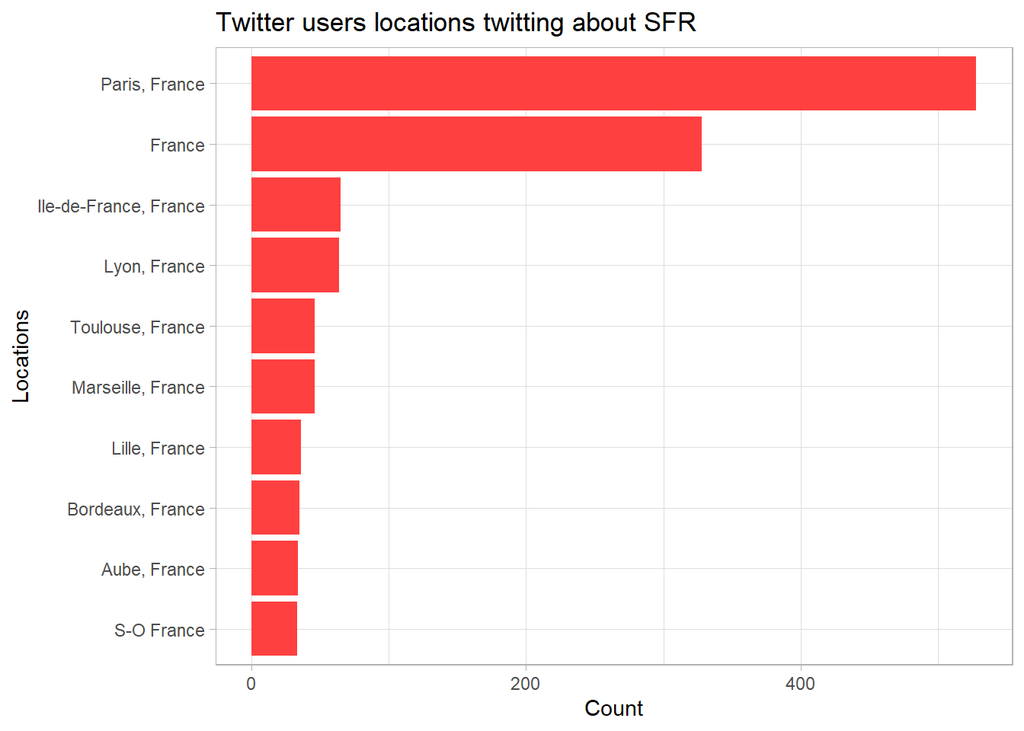

```r
SFRdata %>%count(location2, sort=TRUE) %>%
mutate(location2=reorder(location2,n)) %>%
na.omit()%>% top_n(10)%>%ggplot(aes(x=location2,y=n))+ geom_bar(stat="identity")+ geom_col(fill="brown1")+ coord_flip() +
labs(x = "Locations", y = "Count",
title = "Twitter users locations twitting about SFR")+
theme_light()
```

We can see that most of the tweets are posted from Paris due to the seat location of SFR.

#### Time series of tweets counts

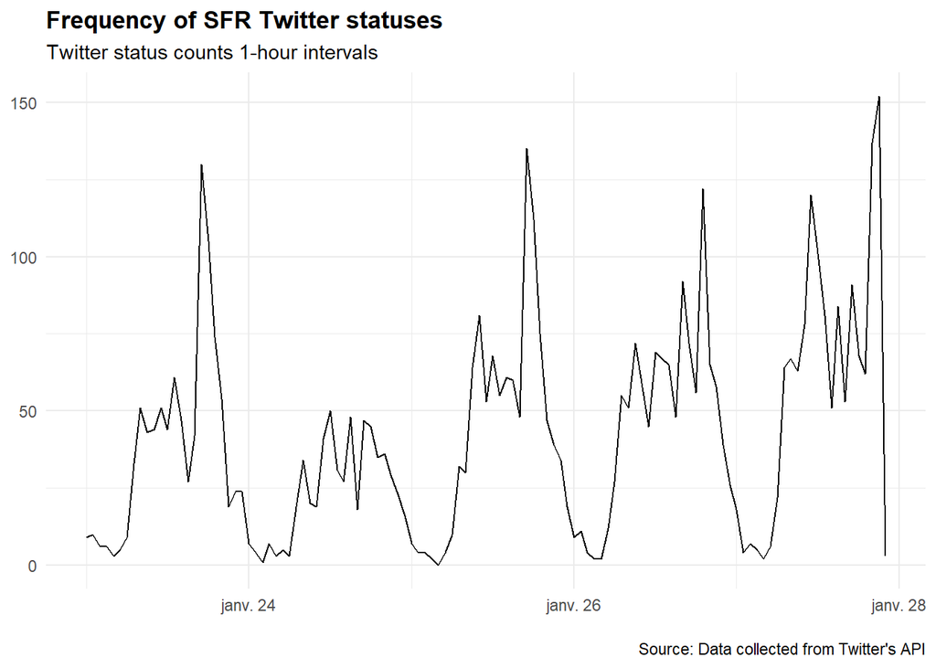

```r
ts_plot(SFRdata, "hours")+
ggplot2::theme_minimal()+
ggplot2::theme(plot.title=ggplot2::element_text(face="bold"))+
ggplot2::labs(x=NULL,y=NULL,
title="Frequency of SFR Twitter statuses",
subtitle="Twitter status counts 1-hour intervals",
caption="\nSource: Data collected from Twitter's API")
```

#### Analysis of the writtors of the different tweets

We convert the orignal dataset to a new dataframe.

```r
tweets.df <-as.data.frame(SFRdata)
print(dim(tweets.df))
```

```
## [1] 5000   91
```

```r
print(colnames(tweets.df))
```

```
##  [1] "user_id"                 "status_id"
##  [3] "created_at"              "screen_name"
##  [5] "text"                    "source"
##  [7] "display_text_width"      "reply_to_status_id"
##  [9] "reply_to_user_id"        "reply_to_screen_name"
## [11] "is_quote"                "is_retweet"
## [13] "favorite_count"          "retweet_count"
## [15] "quote_count"             "reply_count"
## [17] "hashtags"                "symbols"
## [19] "urls_url"                "urls_t.co"
## [21] "urls_expanded_url"       "media_url"
## [23] "media_t.co"              "media_expanded_url"
## [25] "media_type"              "ext_media_url"
## [27] "ext_media_t.co"          "ext_media_expanded_url"
## [29] "ext_media_type"          "mentions_user_id"
```

[output cut: 31 more lines]

Overview of 4 columns of the tweets dataframe

```r
print(tweets.df[1:10,c('created_at','screen_name','is_retweet','hashtags')])
```

```
##             created_at   screen_name is_retweet
## 1  2021-01-27 22:00:14    Pj75Mister       TRUE
## 2  2021-01-27 22:00:03 Ash_ofphoenix      FALSE
## 3  2021-01-27 22:00:03       AlPacQo      FALSE
## 4  2021-01-27 21:59:23      LeLeeLoo      FALSE
## 5  2021-01-27 12:44:25      LeLeeLoo      FALSE
## 6  2021-01-27 12:45:39      LeLeeLoo      FALSE
## 7  2021-01-27 12:41:15      LeLeeLoo      FALSE
## 8  2021-01-27 12:55:46      LeLeeLoo      FALSE
## 9  2021-01-27 21:58:39        Fsorel      FALSE
## 10 2021-01-27 21:58:04     Syrrigald       TRUE
##                                                    hashtags
## 1                                                        NA
## 2                                                        NA
## 3                                                        NA
## 4                                                        NA
## 5                                                        NA
## 6                                                        NA
## 7                                                        NA
## 8                                                        NA
## 9  01drive, 01tv, youtube, 01Tv, SFR, Orange, Free, Fransat
## 10                                                       NA
```

```r
NBperusers <- table(tweets.df$screen_name)
NBperusers<- sort(NBperusers,decreasing=TRUE)
print(NBperusers[1:10])
```

```
##
##        SFR_SAV       REDbySFR    Force_Bleue StephPeyre1985     Un_Forfait
##            209             76             34             33             29
##     MrMartouze pigeon_telecom    DawsonDuval  _Alexandre_06 Alice_Dechelle
##             23             17             16             15             15
```

SFR_SAV and REDbySFR wrote the highest number of tweets.

Number of writtors of tweets:

```r
print(length(unique(tweets.df$screen_name)))
```

```
## [1] 3343
```

Barplot of users who wrote more than 10 tweets

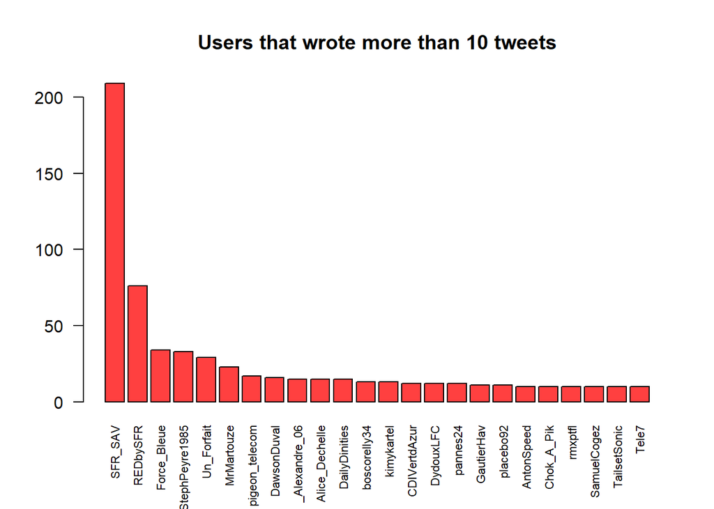

```r
barplot(NBperusers [NBperusers >= 10], las = 2,cex.names=0.7,col="brown1", main="Users that wrote more than 10 tweets")
```

#### Original Tweets without the RT

Number of original tweets among the 5000:

```r
id_original <- which(!tweets.df$is_retweet)
print(length(id_original))
```

```
## [1] 3583
```

Among all these original tweets, we plot a new graph of the most active users.

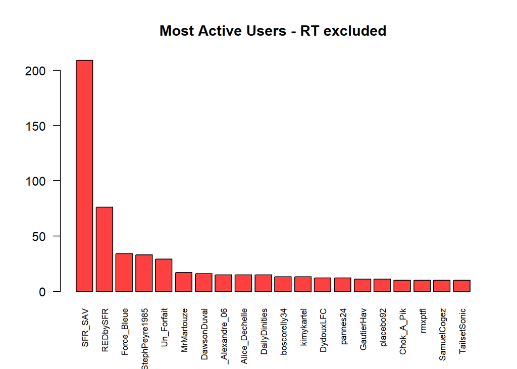

```r
NBperusers_bis <- table(tweets.df$screen_name[id_original])
NBperusers_bis <- sort(NBperusers_bis,decreasing=TRUE)
barplot(NBperusers_bis [NBperusers_bis >= 10], las = 2,cex.names=0.7, col = "brown1", main="Most Active Users - RT excluded")
```

The distribution of users on original tweets is almost the same, especially for the first 5.

### 2.2 Analysis of the Users

We first create a data.frame with the original message in which we remove the duplicate

```r
originalmsg.df <- tweets.df[!duplicated(tweets.df$text),]
```

Number of tweets without duplicate:

```r
print(nrow(originalmsg.df))
```

```
## [1] 3617
```

We collect the messages in a specify vector :

```r
messages <- originalmsg.df$text
print(length(messages))
```

```
## [1] 3617
```

We verification of the lenght of the first element in the vector.

```r
print(messages[1])
```

```
## [1] "merci SFR Pro de merde"
```

We remove the line break, URLs, extra spaces, “", spaces at the end of the line, lowercase, accents, the indicator”RT" and punctuation

```r
msgClean <- iconv(messages, to = "ASCII", sub="")
msgClean <- gsub("\n"," ",messages)
msgClean <- gsub('http\\S+\\s*',"",msgClean)
msgClean <- gsub("\\s+"," ",msgClean)
msgClean <- gsub("[\\]","",msgClean)
msgClean <- gsub("\\s*$","",msgClean)
msgClean <- tolower(msgClean)
msgClean <- gsub("[éèê]","e",msgClean)
msgClean <- gsub("[àâ]","a",msgClean)
msgClean <- gsub("[ùû]","u",msgClean)
msgClean <- gsub("rt ","",msgClean)
```

We check if the changes have been applied on the first element of the vector ‘message’.

```r
print(msgClean[1])
```

```
## [1] "merci sfr pro de merde"
```

We remove the duplicates

```r
msgClean <- msgClean[!duplicated(msgClean)]
```

Numbers of tweets messages:

```r
print(length(msgClean))
```

```
## [1] 3587
```

Isolate each word between spaces

```r
all_words <- unlist(strsplit(msgClean," "))
```

On the text to dermine a user with can looking for “@”

```r
signature_users <- regexpr("^@[[:alnum:]_]*",all_words)
```

```r
list_users <- regmatches(all_words,signature_users)
```

```r
print(length(list_users))
```

```
## [1] 6111
```

Aparition of the users

```r
nb_users <- table(list_users)
sort_nb_users <- sort(nb_users,decreasing=TRUE)
```

Most frequent users

```r
print(sort_nb_users[1:10])
```

```
## list_users
##             @sfr         @sfr_sav        @redbysfr  @pigeon_telecom
##             1090              774              293              145
##      @sheshounet @bouyguestelecom          @orange            @free
##              117              116              101               84
##   @orange_france      @60millions
##               58               55
```

The most frequent user is SFR.

### 2.3 Cluster analysis

```r
usableText <- iconv(SFRdata$text, to = "ASCII", sub="")
SFRdata_corpus<-Corpus(VectorSource(usableText))
SFRdata_corpus<-tm_map(SFRdata_corpus,tolower)
SFRdata_corpus<-tm_map(SFRdata_corpus,function(x)removeWords(x,stopwords("french")))
SFRdata_corpus<-tm_map(SFRdata_corpus,removeWords,c("chez","faire","tout","jai","tout","fait","cest","plus","dites","quand","mme","meme","passe","rien","depuis","pouvez","donc","quoi","via","afin","comme","suivant","suivantes","bonjour","avant"))
SFRdata_corpus<-tm_map(SFRdata_corpus,removeWords,stopwords("french"))
SFRdata_corpus<-tm_map(SFRdata_corpus,removePunctuation)
SFRdata_corpus<-tm_map(SFRdata_corpus,removeNumbers)
```

```r
text_corpus <- tm_map(SFRdata_corpus,content_transformer(function(x) iconv(x,to='ASCII',sub='byte')))
```

```r
SFRdata.tdm <- TermDocumentMatrix(text_corpus)
m <- as.matrix(SFRdata.tdm)
m[1:10,1:10]
```

```
##               Docs
## Terms          1 2 3 4 5 6 7 8 9 10
##   merci        1 0 0 0 0 0 0 0 0  0
##   merde        1 0 0 0 0 0 0 0 0  0
##   pro          1 0 0 0 0 0 0 0 0  0
##   sfr          1 1 1 1 1 1 1 1 1  1
##   aprs         0 1 0 0 0 0 1 0 0  0
##   background   0 1 0 0 0 0 0 0 0  0
##   clients      0 2 0 0 1 0 0 0 0  0
##   compliqu     0 1 0 0 0 0 0 0 0  0
##   curiolog     0 1 0 0 0 0 0 0 0  0
##   fournisseurs 0 1 0 0 0 0 0 0 0  0
```

```r
v <- sort(rowSums(m),decreasing=TRUE)
d <- data.frame(word = names(v),freq=v)
head(d, 50)
```

```
##                            word freq
## sfr                         sfr 4175
## sfrsav                   sfrsav  879
## travail                 travail  798
## redbysfr               redbysfr  440
## bouygues               bouygues  433
## mois                       mois  432
## non                         non  431
## orange                   orange  413
## service                 service  369
## merci                     merci  357
## fibre                     fibre  347
## red                         red  324
## france                   france  324
## forfait                 forfait  293
## travailleurs       travailleurs  287
## box                         box  276
## brsiliens             brsiliens  276
## free                       free  273
## client                   client  272
## frauduleusement frauduleusement  271
## amazon                   amazon  270
## dune                       dune  269
## employer               employer  266
## souponn                 souponn  266
## illgal                   illgal  265
## dclars                   dclars  264
## condamn                 condamn  262
## accident               accident  261
## centaine               centaine  261
## daccidents           daccidents  261
## entrainant           entrainant  261
## logistique           logistique  261
## millier                 millier  261
## probablement       probablement  261
## reconnait             reconnait  261
## priv                       priv  246
## lien                       lien  240
## pigeontelecom     pigeontelecom  207
## jamais                   jamais  206
## bien                       bien  202
## bon                         bon  200
## ensemble               ensemble  197
## tre                         tre  195
## fois                       fois  186
## avoir                     avoir  175
## invite                   invite  175
## point                     point  174
## socit                     socit  174
## tlphone                 tlphone  174
## internet               internet  168
```

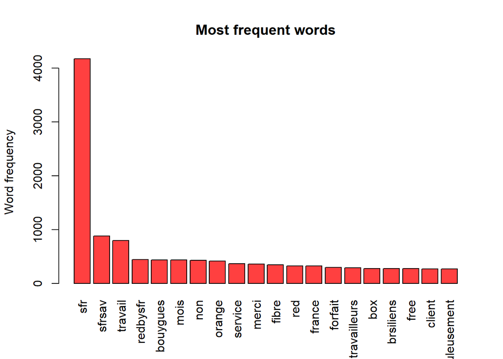

```r
barplot(d[1:20,]$freq, las = 3, names.arg = d[1:20,]$word,col ="brown1", main ="Most frequent words",ylab = "Word frequency")
```

SFR is the most frequent word which is normal considering that we used it to do the extraction. We still find words related to the customers services but also linked to the main competitors of SFR such as Free and Orange.

```r
print(text_corpus[[1]]$content)
```

```
## [1] "merci sfr pro  merde"
```

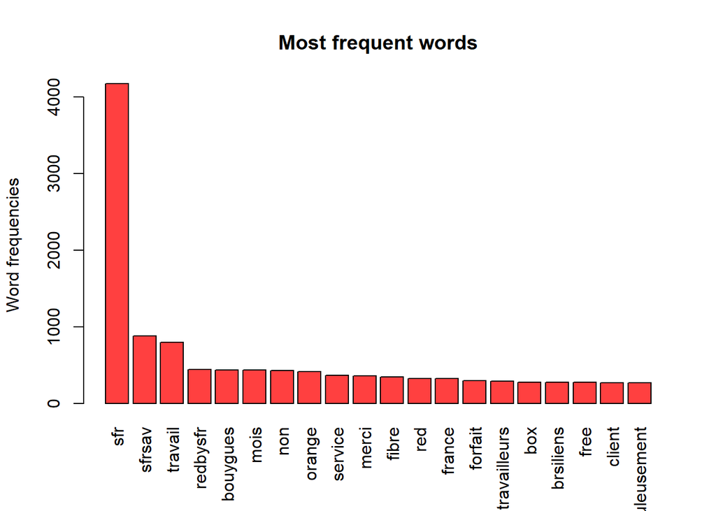

```r
barplot(d[1:20,]$freq, las = 3,
names.arg = d[1:20,]$word,col ="brown1 ",
main ="Most frequent words",
ylab = "Word frequencies")
```

```r
SFRdata.tdm
```

```
## <<TermDocumentMatrix (terms: 9422, documents: 5000)>>
## Non-/sparse entries: 63331/47046669
## Sparsity           : 100%
## Maximal term length: 58
## Weighting          : term frequency (tf)
```

```r
findFreqTerms(SFRdata.tdm, lowfreq=10)[1:10]
```

```
##  [1] "merci"    "merde"    "pro"      "sfr"      "aprs"     "clients"
##  [7] "compliqu" "service"  "services" "tant"
```

```r
SFRdata.tdm<-removeSparseTerms(SFRdata.tdm,sparse=0.95)
SFRdata.df <- as.data.frame(as.matrix(SFRdata.tdm))
```

```r
SFRdata.df.scale <- scale(SFRdata.df)
SFRdata.dist <- dist(SFRdata.df.scale,method = "euclidean")
```

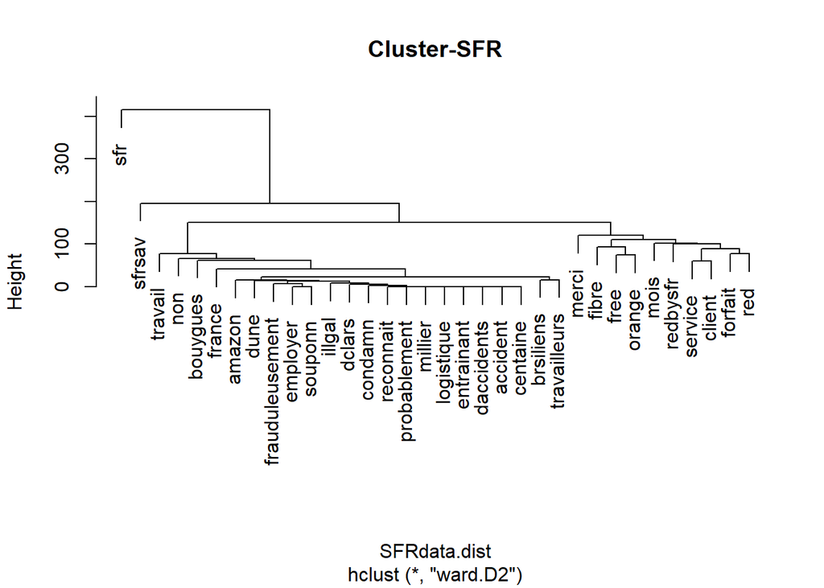

```r
SFRdata.fit<-hclust(SFRdata.dist, method="ward.D2")
plot(SFRdata.fit, main="Cluster-SFR")
```

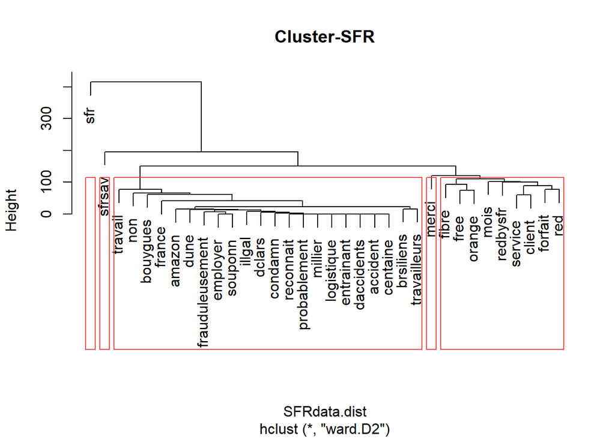

```r
groups <- cutree(SFRdata.fit, k=5)
plot(SFRdata.fit, main="Cluster-SFR")
rect.hclust(SFRdata.fit, k=5, border="brown1")
```

### 2.4 Hashtag Analysis

A word can be considerate as un Hastag if it begins with “#”.

```r
signature_hashtag <- regexpr("^#[[:alnum:]_]*",all_words)
list_hashtag <- regmatches(all_words,signature_hashtag)
```

Number of hastags:

```r
print(length(list_hashtag))
```

```
## [1] 769
```

In order to know what the most used hashtag, we create a list of hashtag and sort the frequency in descending order.

```r
nb_hashtags <- table(list_hashtag)
sort_nb_hashtags <- sort(nb_hashtags,decreasing=TRUE)
hash = print(sort_nb_hashtags[1:10])
```

```
## list_hashtag
##        #sfr   #redbysfr         #5g  #audiences        #red     #orange
##         117          26          24          15          15          14
## #freemobile      #nperf    #bonplan      #fibre
##           9           9           8           8
```

Displayed of the 10 most frequent hashtags.

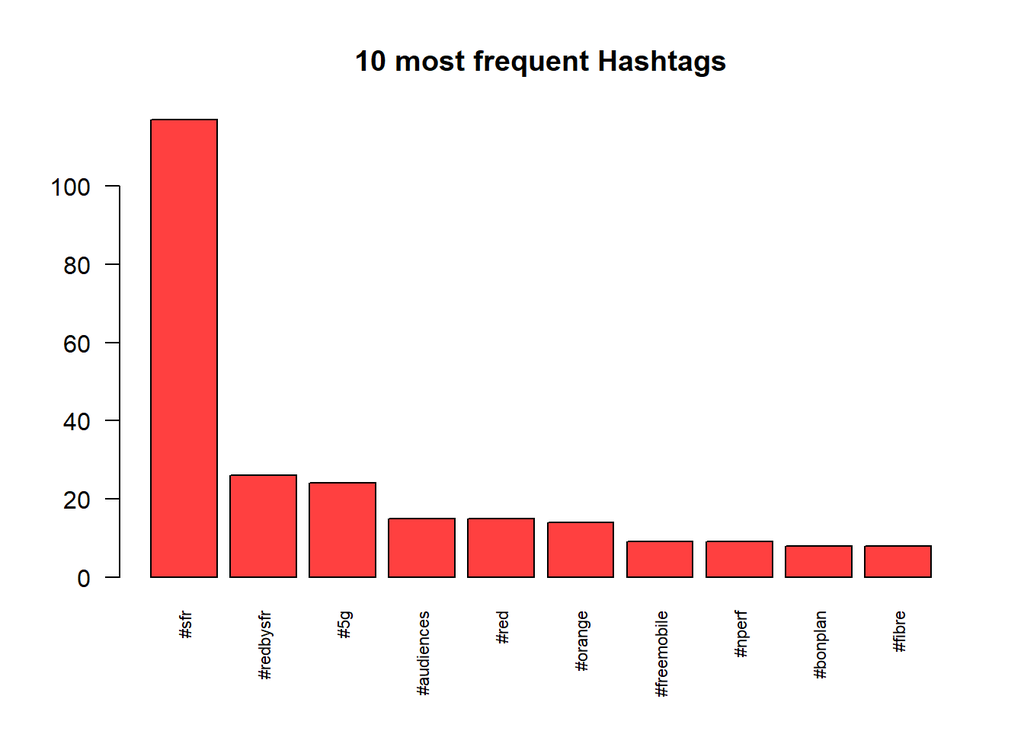

```r
barplot(sort(hash,decreasing=TRUE),las=2,cex.names=0.7,col="brown1", main='10 most frequent Hashtags')
```

SFR is the most frequent hashtag which seems normal concidering the fact that we use this word to do the extractaction. One of the most frequent Hashtag is 5G.

We display a wordcloud of the most frequent hashtags.

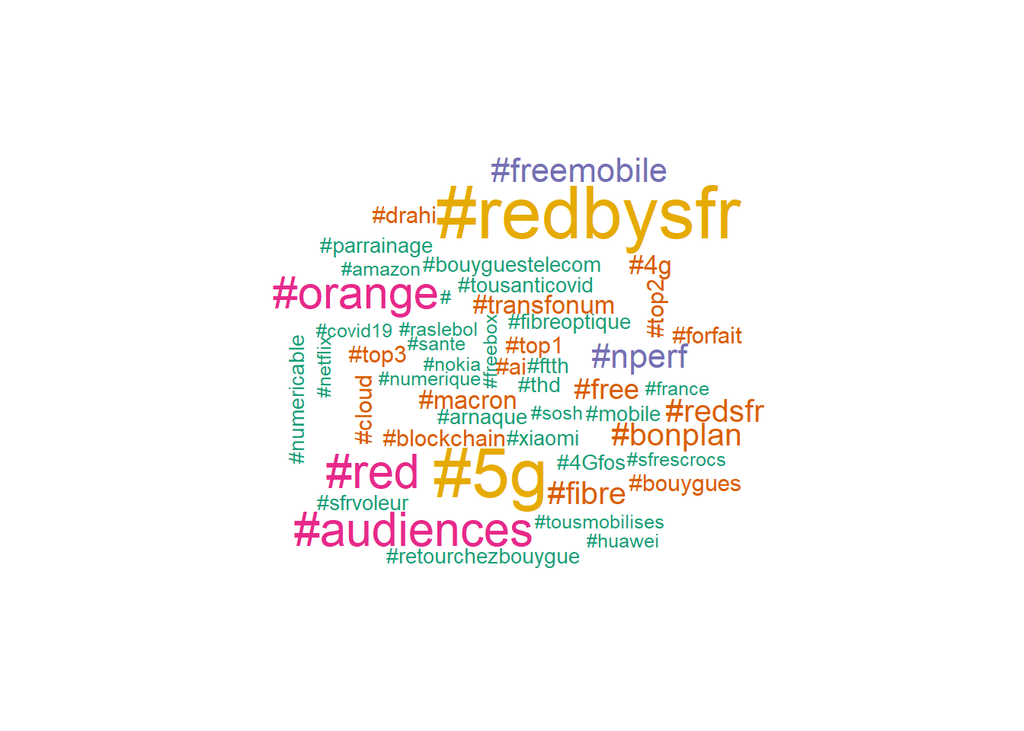

```r
wordcloud(names(sort_nb_hashtags)[-1],sort_nb_hashtags[-1],scale=c(3,.5),colors=brewer.pal(6, "Dark2"))
```

List of hashtags with 5G and their apparition

```r
hashtags_5g<- nb_hashtags[grep("5g",names(nb_hashtags))]
print(sort(hashtags_5g,decreasing=TRUE))
```

```
## list_hashtag
##         #5g #mi10tpro5g
##          24           2
```

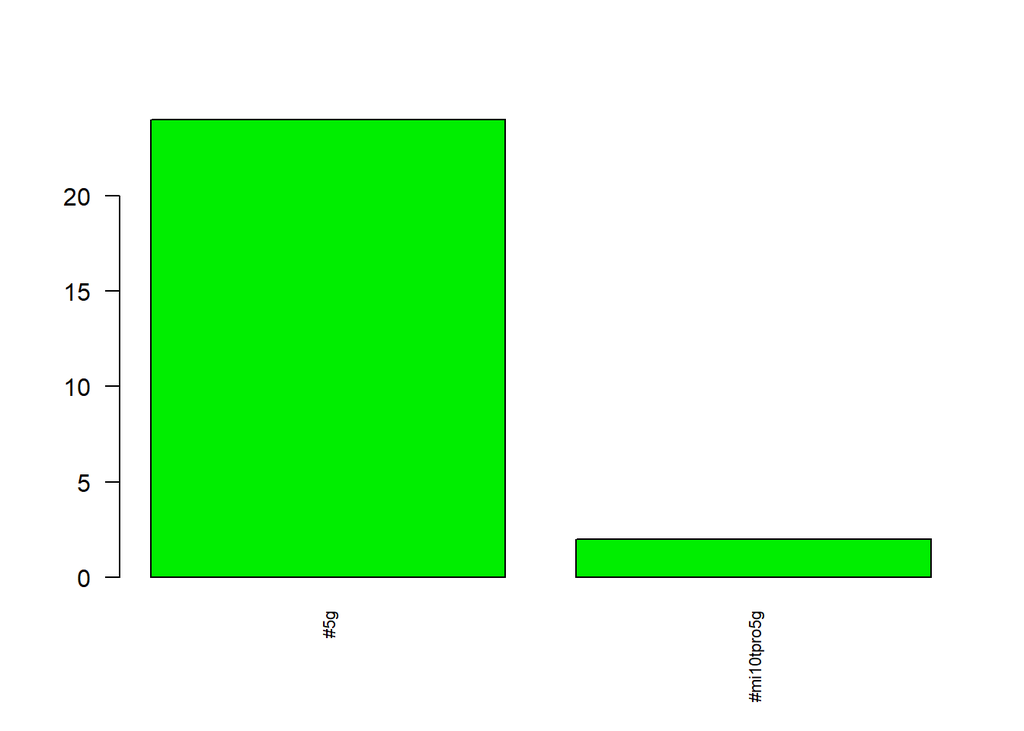

```r
barplot(sort(hashtags_5g,decreasing=TRUE),las=2,cex.names=0.7,col="green2")
```

#### Hashtag network

```r
tags<-function(x) toupper(grep("#",strsplit(x," +")[[1]],value=TRUE))
l <- nrow(SFRdata)
taglist <- vector(mode = "list", l)
texts <- vector(mode = "character", length = l)

for (i in 1:l) texts[i] <- SFRdata$text[i]
texts <- iconv(texts, to = "ASCII", sub="")
```

```r
j<-0
for(i in 1:l){
  if(is.na(str_match(texts[i],"#"))[1,1]==FALSE){
    j<-j+1
    taglist[[j]]<-str_squish(removePunctuation(tags(ifelse(is.na(str_match(texts[i], "[\n]")[1,1])==TRUE,texts[i],gsub("[\n]"," ", texts[i])))))
  }
}

alltags <- NULL
for (i in 1:l) alltags<-union(alltags,taglist[[i]])

hash.graph <- graph.empty(directed = T)

hash.graph <- hash.graph + vertices(alltags)
```

```r
for (tags in taglist){
  if (length(tags)>1){
    for (pair in combn(length(tags),2,simplify=FALSE, FUN=function(x) sort(tags[x]))){
      if (pair[1]!=pair[2]) {
        if (hash.graph[pair[1],pair[2]]==0)
          hash.graph<-hash.graph+edge(pair[1],pair[2])
      }
    }
  }
}


V(hash.graph)$color <- "blue"
E(hash.graph)$color <- "black"
V(hash.graph)$name <- paste("#",V(hash.graph)$name, sep = "")
V(hash.graph)$label.cex = 0.75
V(hash.graph)$size <- 12
V(hash.graph)$size2 <- 12
hash.graph_simple<-delete.vertices(simplify(hash.graph),
degree(hash.graph)<=20)
```

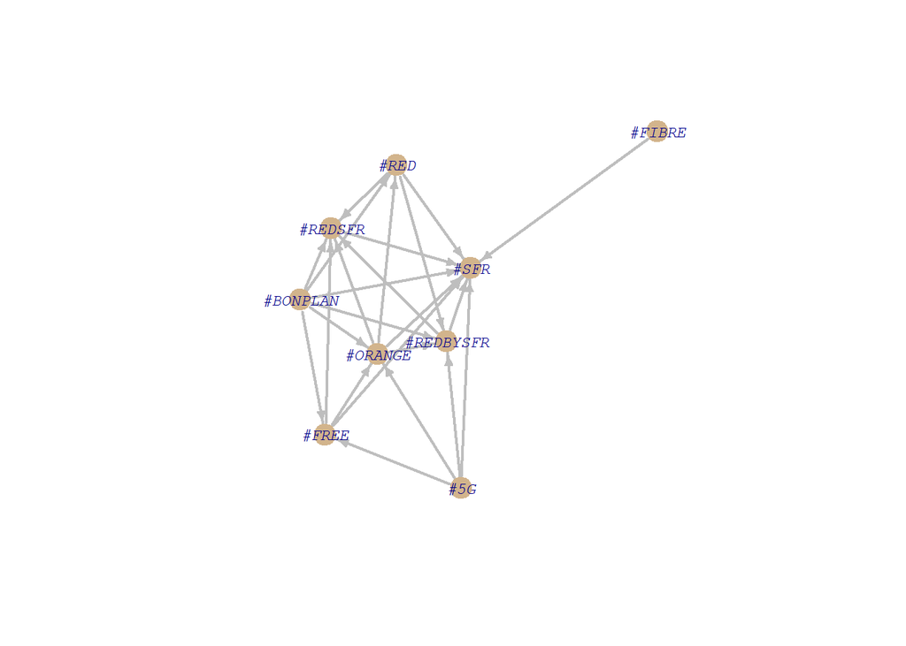

```r
plot(hash.graph_simple, edge.width = 2,
edge.color = "grey", vertex.color = "tan",
vertex.frame.color="tan", label.color = "blue",
vertex.label.font=12, edge.arrow.size=0.5)
```

The hashtag “BONPLAN” can show us that SFR may be the most attractive french operator. Possibily due to affordable offers such as RedbySfr.

### 2.5 Sentiment analysis

```r
plain.text<-vector()
for(i in 1:dim(SFRdata)[1]){
  plain.text[i]<-SFRdata_corpus[[i]][[1]]
}
sentence_sentiment<-sentiment(get_sentences(plain.text))
sentence_sentiment
```

```
##       element_id sentence_id word_count  sentiment
##    1:          1           1          4 0.50000000
##    2:          2           1         20 0.00000000
##    3:          3           1          9 0.03333333
##    4:          4           1          9 0.13333333
##    5:          5           1         22 0.00000000
##   ---
## 4996:       4996           1          7 0.00000000
## 4997:       4997           1         22 0.00000000
## 4998:       4998           1         14 0.26726124
## 4999:       4999           1         10 0.00000000
## 5000:       5000           1          5 0.00000000
```

```r
average_sentiment<-mean(sentence_sentiment$sentiment)
average_sentiment
```

```
## [1] 0.009253099
```

The sentiment score is positive but very close to zero so we can say that it is globally neutral. We can explain the result due to the huge amount of answers to unsatisfied clients.

```r
sd_sentiment<-sd(sentence_sentiment$sentiment)
sd_sentiment
```

```
## [1] 0.1544881
```

The standard deviation of the sentiment score is close to 0, the values are not scattered.

```r
extract_sentiment_terms(get_sentences(plain.text))
```

```
##       element_id sentence_id negative positive
##    1:          1           1               pro
##    2:          2           1
##    3:          3           1      bug   encore
##    4:          4           1          continue
##    5:          5           1
##   ---
## 4996:       4996           1
## 4997:       4997           1
## 4998:       4998           1               pro
## 4999:       4999           1
## 5000:       5000           1
```

### 2.6 Topic Modeling

```r
text_corpus2<-text_corpus[1:200]
doc.lengths<-rowSums(as.matrix(DocumentTermMatrix(text_corpus2)))
dtm <- DocumentTermMatrix(text_corpus2[doc.lengths > 0])
```

```r
SEED = sample(1:1000000, 1)
```

```r
k = 2
Topics_results<-LDA(dtm, k = k, control = list(seed = SEED))
```

```r
terms(Topics_results,15)
```

```
##       Topic 1    Topic 2
##  [1,] "sfr"      "sfr"
##  [2,] "merde"    "sfrsav"
##  [3,] "merci"    "mistermv"
##  [4,] "pro"      "fibre"
##  [5,] "sfrsav"   "service"
##  [6,] "box"      "clients"
##  [7,] "red"      "redbysfr"
##  [8,] "bon"      "client"
##  [9,] "coupure"  "point"
## [10,] "fibre"    "allauch"
## [11,] "redbysfr" "bien"
## [12,] "monde"    "direct"
## [13,] "contre"   "dploiement"
## [14,] "evitez"   "technicien"
## [15,] "mobile"   "tous"
```

```r
topics(Topics_results)
```

```
##   1   2   3   4   5   6   7   8   9  10  11  12  13  14  15  16  17  18  19  20
##   1   2   1   2   2   2   2   2   2   1   1   1   1   2   1   1   1   2   1   1
##  21  22  23  24  25  26  27  28  29  30  31  32  33  34  35  36  37  38  39  40
##   2   2   2   1   2   1   2   2   2   1   1   1   1   1   1   2   2   1   2   1
##  41  42  43  44  45  46  47  48  49  50  51  52  53  54  55  56  57  58  59  60
##   1   1   2   1   1   1   1   1   2   1   2   1   1   2   1   2   2   2   1   2
##  61  62  63  64  65  66  67  68  69  70  71  72  73  74  75  76  77  78  79  80
##   2   2   1   2   1   1   1   2   1   1   1   1   2   1   2   2   2   1   1   1
##  81  82  83  84  85  86  87  88  89  90  91  92  93  94  95  96  97  98  99 100
##   1   2   2   1   1   2   1   1   2   2   1   2   1   2   2   2   2   2   1   1
## 101 102 103 104 105 106 107 108 109 110 111 112 113 114 115 116 117 118 119 120
##   2   1   1   2   2   1   2   1   1   2   1   1   1   1   1   1   2   2   2   1
## 121 122 123 124 125 126 127 128 129 130 131 132 133 134 135 136 137 138 139 140
##   2   2   1   2   2   1   1   1   1   1   1   2   1   2   2   1   1   1   2   1
## 141 142 143 144 145 146 147 148 149 150 151 152 153 154 155 156 157 158 159 160
##   1   2   2   1   1   2   1   1   2   1   1   1   1   1   2   2   1   1   2   1
## 161 162 163 164 165 166 167 168 169 170 171 172 173 174 175 176 177 178 179 180
##   2   1   2   2   1   1   1   2   1   2   1   2   1   1   1   2   1   1   2   1
## 181 182 183 184 185 186 187 188 189 190 191 192 193 194 195 196 197 198 199 200
##   1   2   1   1   1   2   1   1   1   2   1   1   1   1   1   1   2   2   1   1
```

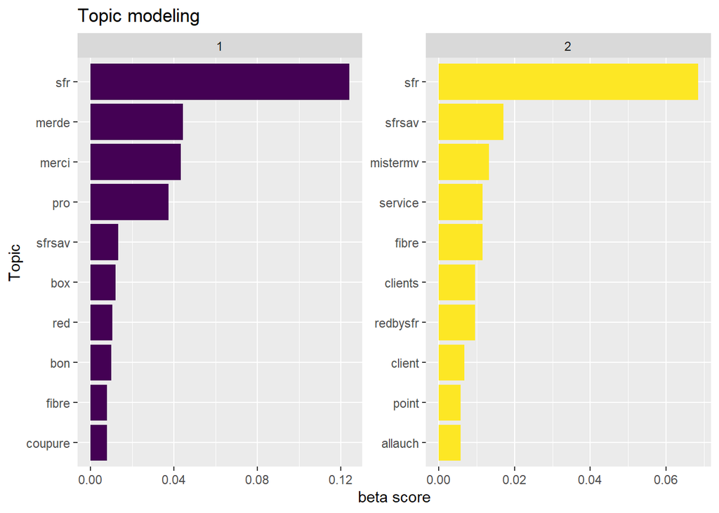

```r
tidy_model_beta<-tidy(Topics_results, matrix = "beta")
tidy_model_beta %>%
  group_by(topic) %>%
  top_n(10, beta) %>%
  ungroup() %>%
  arrange(topic, -beta) %>%
  ggplot(aes(reorder(term, beta),beta,fill=factor(topic)))+
  geom_col(show.legend = FALSE) +
  facet_wrap(~ topic, scales = "free") +
  scale_fill_viridis_d() +
  coord_flip() +
  labs(x = "Topic",
       y = "beta score",
       title = "Topic modeling")
```

## 3. BouyguesTelecom data Analysis

### 3.1 Clean and Exploratory analysis

```r
class(Bouyguedata)
```

```
## [1] "tbl_df"     "tbl"        "data.frame"
```

```r
head(Bouyguedata, n=10)
```

```
## # A tibble: 10 x 90
##    user_id status_id created_at          screen_name text  source
##    <chr>   <chr>     <dttm>              <chr>       <chr> <chr>
##  1 100552~ 13545495~ 2021-01-27 21:59:20 taintain44  "@sp~ Twitt~
##  2 305865~ 13545495~ 2021-01-27 21:59:09 domichauve~ "Que~ Twitt~
##  3 425342~ 13545473~ 2021-01-27 21:50:30 babache_42  "@bo~ Twitt~
##  4 489694~ 13545469~ 2021-01-27 21:48:58 HabiibCR    "Je ~ Twitt~
##  5 489694~ 13541595~ 2021-01-26 20:09:34 HabiibCR    "@Zi~ Twitt~
##  6 134872~ 13544928~ 2021-01-27 18:14:01 Dumieletdu~ "@Ku~ Twitt~
##  7 134872~ 13544927~ 2021-01-27 18:13:32 Dumieletdu~ "@Ku~ Twitt~
##  8 134872~ 13544926~ 2021-01-27 18:13:17 Dumieletdu~ "@Ku~ Twitt~
##  9 134872~ 13543613~ 2021-01-27 09:31:21 Dumieletdu~ "7èm~ Twitt~
## 10 134872~ 13544853~ 2021-01-27 17:44:11 Dumieletdu~ "@Ku~ Twitt~
## # ... with 84 more variables: display_text_width <dbl>,
## #   reply_to_status_id <chr>, reply_to_user_id <chr>,
## #   reply_to_screen_name <chr>, is_quote <lgl>, is_retweet <lgl>,
## #   favorite_count <int>, retweet_count <int>, quote_count <int>,
## #   reply_count <int>, hashtags <list>, symbols <list>, urls_url <list>,
## #   urls_t.co <list>, urls_expanded_url <list>, media_url <list>,
## #   media_t.co <list>, media_expanded_url <list>, media_type <list>,
## #   ext_media_url <list>, ext_media_t.co <list>, ext_media_expanded_url <list>,
## #   ext_media_type <chr>, mentions_user_id <list>, mentions_screen_name <list>,
## #   lang <chr>, quoted_status_id <chr>, quoted_text <chr>,
## #   quoted_created_at <dttm>, quoted_source <chr>, quoted_favorite_count <int>,
## #   quoted_retweet_count <int>, quoted_user_id <chr>, quoted_screen_name <chr>,
## #   quoted_name <chr>, quoted_followers_count <int>,
## #   quoted_friends_count <int>, quoted_statuses_count <int>,
## #   quoted_location <chr>, quoted_description <chr>, quoted_verified <lgl>,
## #   retweet_status_id <chr>, retweet_text <chr>, retweet_created_at <dttm>,
## #   retweet_source <chr>, retweet_favorite_count <int>,
## #   retweet_retweet_count <int>, retweet_user_id <chr>,
## #   retweet_screen_name <chr>, retweet_name <chr>,
## #   retweet_followers_count <int>, retweet_friends_count <int>,
## #   retweet_statuses_count <int>, retweet_location <chr>,
## #   retweet_description <chr>, retweet_verified <lgl>, place_url <chr>,
## #   place_name <chr>, place_full_name <chr>, place_type <chr>, country <chr>,
## #   country_code <chr>, geo_coords <list>, coords_coords <list>,
## #   bbox_coords <list>, status_url <chr>, name <chr>, location <chr>,
## #   description <chr>, url <chr>, protected <lgl>, followers_count <int>,
## #   friends_count <int>, listed_count <int>, statuses_count <int>,
## #   favourites_count <int>, account_created_at <dttm>, verified <lgl>,
## #   profile_url <chr>, profile_expanded_url <chr>, account_lang <lgl>,
## #   profile_banner_url <chr>, profile_background_url <chr>,
## #   profile_image_url <chr>
```

```r
length(unique(Bouyguedata$location))
```

```
## [1] 692
```

Removing special character in non latin language and remove to na.omit, and clean the name of the cities.

```r
Bouyguedata$location2<-iconv(Bouyguedata$location,to = "ASCII", sub="")
```

Location list

```r
Bouyguedata$location2[Bouyguedata$location2==""]<- NA
Bouyguedata$location2[Bouyguedata$location2==", "]<- NA
Bouyguedata$location2[Bouyguedata$location2=="Paris"]<- "Paris, France"
Bouyguedata$location2[Bouyguedata$location2=="Comparateur de forfait Mobile"]<- NA
Bouyguedata$location2[Bouyguedata$location2=="Bordeaux"]<- "Bordeaux, France"
Bouyguedata$location2[Bouyguedata$location2=="Marseille"]<- "Marseille, France"
Bouyguedata$location2[Bouyguedata$location2=="Nice"]<- "Nice, France"
Bouyguedata$location2[Bouyguedata$location2=="Lille"]<- "Lille, France"
Bouyguedata$location2[Bouyguedata$location2=="Lyon"]<- "Lyon, France"
Bouyguedata$location2[Bouyguedata$location2=="Toulouse"]<- "Toulouse, France"
```

#### Twitter users - Unique locations

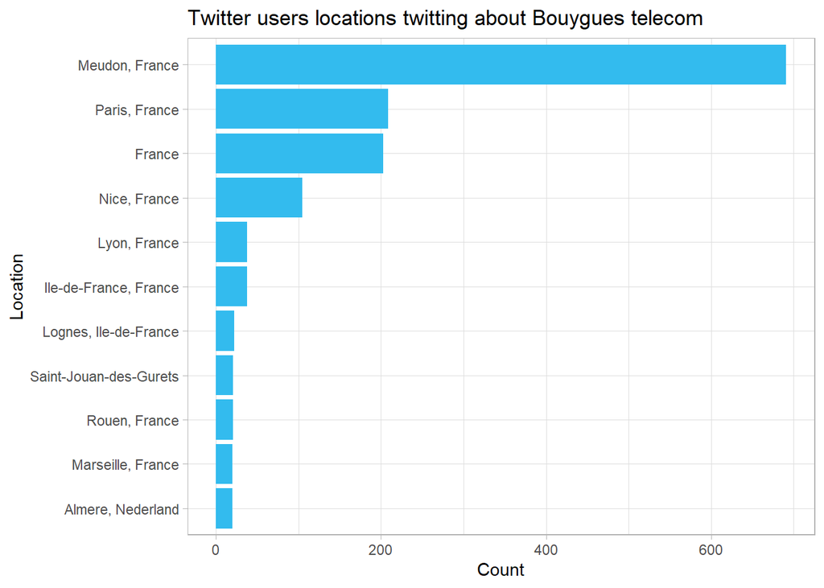

```r
Bouyguedata %>%count(location2, sort=TRUE) %>%
mutate(location2=reorder(location2,n)) %>%
na.omit()%>% top_n(10)%>%ggplot(aes(x=location2,y=n))+ geom_bar(stat="identity")+ geom_col(fill='#33BBEE')+ coord_flip() +
labs(x = "Location", y = "Count",title = "Twitter users locations twitting about Bouygues telecom")+ theme_light()
```

The seat of Bouygues Telecom is at Meudon, it explains the first position of Meudon on the barplot.

#### Time Series of tweets counts

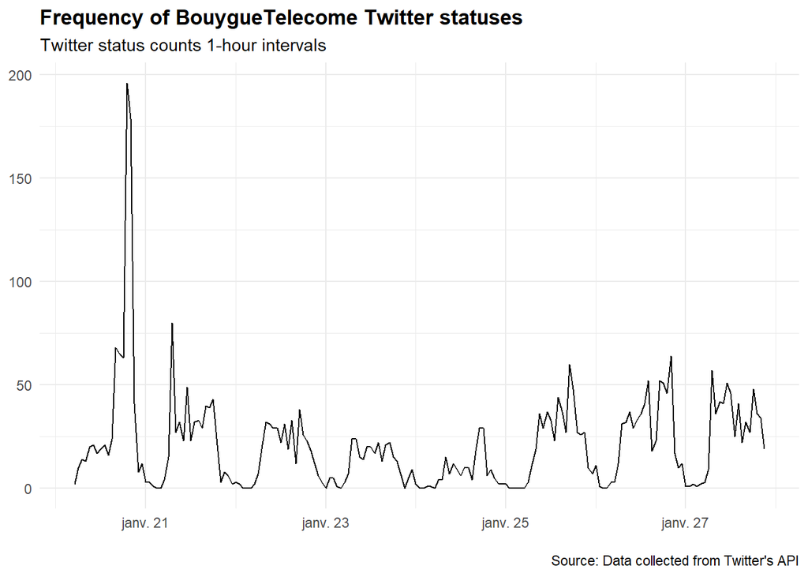

```r
ts_plot(Bouyguedata, "hours")+
ggplot2::theme_minimal()+
ggplot2::theme(plot.title=ggplot2::element_text(face="bold"))+
ggplot2::labs(x=NULL,y=NULL,
title="Frequency of BouygueTelecome Twitter statuses",
subtitle="Twitter status counts 1-hour intervals",
caption="\nSource: Data collected from Twitter's API")
```

We can explain the high pic at the end of the day of the 20 of January due to a huge network failure. A lot of twitter users has wrote directly to the Bouygues Telecom account.

#### Analysis of the writtors of the different tweets

```r
Bygtweets.df <-as.data.frame(Bouyguedata)
print(dim(Bygtweets.df))
```

```
## [1] 3888   91
```

```r
print(colnames(Bygtweets.df))
```

```
##  [1] "user_id"                 "status_id"
##  [3] "created_at"              "screen_name"
##  [5] "text"                    "source"
##  [7] "display_text_width"      "reply_to_status_id"
##  [9] "reply_to_user_id"        "reply_to_screen_name"
## [11] "is_quote"                "is_retweet"
## [13] "favorite_count"          "retweet_count"
## [15] "quote_count"             "reply_count"
## [17] "hashtags"                "symbols"
## [19] "urls_url"                "urls_t.co"
## [21] "urls_expanded_url"       "media_url"
## [23] "media_t.co"              "media_expanded_url"
## [25] "media_type"              "ext_media_url"
## [27] "ext_media_t.co"          "ext_media_expanded_url"
## [29] "ext_media_type"          "mentions_user_id"
```

[output cut: 31 more lines]

```r
print(Bygtweets.df[1:10,c('created_at','screen_name','is_retweet','hashtags')])
```

```
##             created_at     screen_name is_retweet hashtags
## 1  2021-01-27 21:59:20      taintain44      FALSE       NA
## 2  2021-01-27 21:59:09    domichauveau       TRUE       NA
## 3  2021-01-27 21:50:30      babache_42      FALSE       NA
## 4  2021-01-27 21:48:58        HabiibCR      FALSE       NA
## 5  2021-01-26 20:09:34        HabiibCR      FALSE       NA
## 6  2021-01-27 18:14:01 Dumieletdusole1      FALSE       NA
## 7  2021-01-27 18:13:32 Dumieletdusole1      FALSE       NA
## 8  2021-01-27 18:13:17 Dumieletdusole1      FALSE       NA
## 9  2021-01-27 09:31:21 Dumieletdusole1      FALSE       NA
## 10 2021-01-27 17:44:11 Dumieletdusole1      FALSE       NA
```

```r
NBperusersByg <- table(Bygtweets.df$screen_name)
NBperusersByg<- sort(NBperusersByg,decreasing=TRUE)
print(NBperusersByg[1:10])
```

```
##
## bouyguestelecom      BassSpleen  fibre2021allez Dumieletdusole1       Bobfigo77
##             690              49              26              24              22
##       Ls_SwayZz        Kugucu95  Outman_echarki     idefix_spqr          Kyzox6
##              21              20              20              17              15
```

Bouyguestelecom and BassSpleen wrote the highest number of tweets.

Number of writtors of tweets during the last 7 days:

```r
print(length(unique(Bygtweets.df$screen_name)))
```

```
## [1] 1809
```

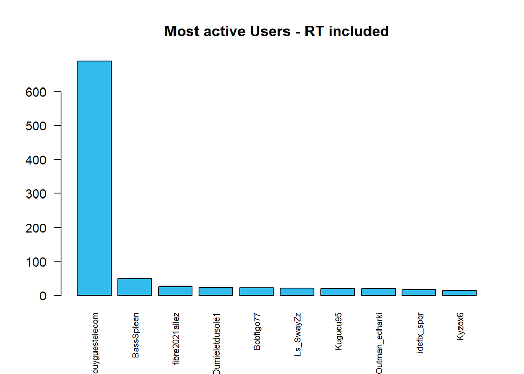

```r
barplot(NBperusersByg [NBperusersByg >= 15], las = 2,cex.names=0.7,col="#33BBEE", main='Most active Users - RT included')
```

#### Original Tweets without the RT

How many tweets among all those collected are original tweets,not retweets?

```r
id_originalByg <- which(!Bygtweets.df$is_retweet)
print(length(id_originalByg))
```

```
## [1] 3539
```

Number of original tweets per users

```r
NBperusers_Byg <- table(Bygtweets.df$screen_name[id_originalByg])
NBperusers_Byg <- sort(NBperusers_Byg,decreasing=TRUE)
```

Barplot of users that wrote more than 15 tweets (RT excluded)

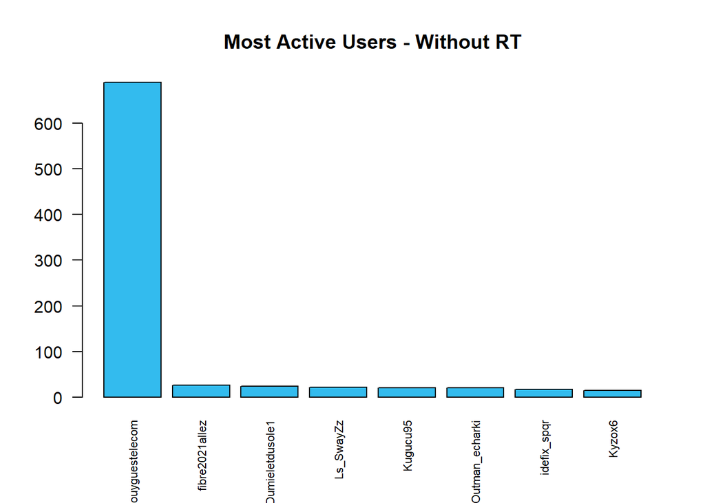

```r
barplot(NBperusers_Byg [NBperusers_Byg >= 15], las = 2,cex.names=0.7, col = "#33BBEE", main='Most Active Users - Without RT')
```

### 3.2 Analyse of the Users

We first create a data.frame with the original message Removing of the duplicate

```r
originalmsgByg.df <- Bygtweets.df[!duplicated(Bygtweets.df$text),]
```

Number of tweets without duplicate:

```r
print(nrow(originalmsgByg.df))
```

```
## [1] 3535
```

We collect these messages in a specify vector :

```r
messagesByg <- originalmsgByg.df$text
```

```r
print(length(messagesByg))
```

```
## [1] 3535
```

Verification of the lenght

```r
print(messagesByg[520])
```

```
## [1] "@Flan2VO Bonjour, pour vous répondre au mieux, pouvez-vous nous préciser votre demande et le n° de la ligne concernée en privé svp ? 👇\nhttps://t.co/V5I5alwEpF"
```

```r
msgCleanByg <- iconv(messagesByg, to = "ASCII", sub="")
msgCleanByg <- gsub("\n"," ",messagesByg)
msgCleanByg <- gsub('http\\S+\\s*',"",msgCleanByg)
msgCleanByg <- gsub("\\s+"," ",msgCleanByg)
msgCleanByg <- gsub("[\\]","",msgCleanByg)
msgCleanByg <- gsub("\\s*$","",msgCleanByg)
msgCleanByg <- tolower(msgCleanByg)
msgCleanByg <- gsub("[Ã©Ã¨Ãª]","e",msgCleanByg)
msgCleanByg <- gsub("[Ã Ã¢]","a",msgCleanByg)
msgCleanByg <- gsub("[Ã¹Ã»]","u",msgCleanByg)
msgCleanByg <- gsub("rt ","",msgCleanByg)
```

Verification of the message 520

```r
print(msgCleanByg[520])
```

```
## [1] "@flan2vo bonjour, pour vous répondre au mieux, pouvez-vous nous préciser votre demande et le n° de la ligne concernée en privé svp ? 👇<ed>¹. l'offre est disponible uniquement sur le site bonne journée. elodie"
```

Remove of the duplicates

```r
msgCleanByg <- msgCleanByg[!duplicated(msgCleanByg)]
```

Numbers of tweets messages

```r
print(length(msgCleanByg))
```

```
## [1] 3516
```

Isolate each word between spaces

```r
all_wordsByg <- unlist(strsplit(msgCleanByg," "))
```

On the text to determine a user we can look for “@”

```r
signature_usersByg <- regexpr("^@[[:alnum:]_]*",all_wordsByg)
```

```r
list_usersByg <- regmatches(all_wordsByg,signature_usersByg)
```

```r
print(length(list_usersByg))
```

```
## [1] 6529
```

Aparition of the users

```r
nb_usersByg <- table(list_usersByg)
sort_nb_usersByg <- sort(nb_usersByg,decreasing=TRUE)
```

Most frequent user

```r
print(sort_nb_usersByg[1:10])
```

```
## list_usersByg
## @bouyguestelecom             @sfr            @free          @orange
##             2641              140              132              123
##   @orange_france      @freemobile         @freebox        @redbysfr
##               89               86               77               69
##      @b_s_julien        @urlututu
##               62               52
```

### 3.3 Cluster analysis

```r
usableTextByg <- iconv(Bouyguedata$text, to = "ASCII", sub="")
Bouyguedata_corpus<-Corpus(VectorSource(usableTextByg))
Bouyguedata_corpus<-tm_map(Bouyguedata_corpus,tolower)
Bouyguedata_corpus<-tm_map(Bouyguedata_corpus,function(x)removeWords(x,stopwords("french")))
Bouyguedata_corpus<-tm_map(Bouyguedata_corpus,removePunctuation)
Bouyguedata_corpus<-tm_map(Bouyguedata_corpus,removeNumbers)
Bouyguedata_corpus<-tm_map(Bouyguedata_corpus,removeWords,c("chez","faire","tout","jai","tout","fait","cest","plus","dites","quand","mme","meme","passe","rien","depuis","pouvez","svp","bjr","bonjour"))

text_corpusByg <- tm_map(Bouyguedata_corpus,content_transformer(function(x) iconv(x,to='ASCII',sub='byte')))
```

```r
Bouyguedata.tdm <- TermDocumentMatrix(text_corpusByg)
m <- as.matrix(Bouyguedata.tdm)
m[1:10,1:10]
```

```
##                  Docs
## Terms             1 2 3 4 5 6 7 8 9 10
##   bouyguestelecom 1 1 1 1 1 1 1 1 0  1
##   capitaine       1 0 0 0 0 0 0 0 0  0
##   colre           1 0 0 0 0 0 0 0 0  0
##   haddock         1 0 0 0 0 0 0 0 0  0
##   spacegraphics   1 0 0 0 0 0 0 0 0  0
##   box             0 1 0 0 0 0 0 0 0  0
##   cher            0 1 0 0 0 0 0 0 0  0
##   clair           0 1 0 0 0 0 0 0 0  0
##   consorts        0 1 0 0 0 0 0 0 0  0
##   darrter         0 1 0 0 0 0 0 0 0  0
```

```r
v <- sort(rowSums(m),decreasing=TRUE)
d <- data.frame(word = names(v),freq=v)
head(d, 50)
```

```
##                            word freq
## bouyguestelecom bouyguestelecom 2963
## bouygues               bouygues  448
## merci                     merci  324
## priv                       priv  292
## ligne                     ligne  280
## rseau                     rseau  258
## sfr                         sfr  248
## rpondre                 rpondre  248
## httpscovialwepf httpscovialwepf  246
## telecom                 telecom  245
## free                       free  244
## box                         box  228
## internet               internet  228
## mois                       mois  220
## forfait                 forfait  215
## orange                   orange  210
## fibre                     fibre  209
## service                 service  208
## bien                       bien  191
## concerne               concerne  181
## messages               messages  179
## avoir                     avoir  164
## client                   client  163
## suivre                   suivre  161
## recevoir               recevoir  157
## tlphone                 tlphone  153
## privs                     privs  151
## essayons               essayons  149
## puissiez               puissiez  149
## panne                     panne  137
## problme                 problme  134
## offre                     offre  133
## tous                       tous  120
## non                         non  118
## aussi                     aussi  118
## pensez                   pensez  118
## demande                 demande  115
## toujours               toujours  115
## tre                         tre  114
## mobile                   mobile  114
## indiquer               indiquer  110
## point                     point  110
## jours                     jours  108
## bonne                     bonne  108
## bon                         bon  107
## alors                     alors  106
## journe                   journe  106
## mieux                     mieux  101
## bbox                       bbox  101
## aprs                       aprs  100
```

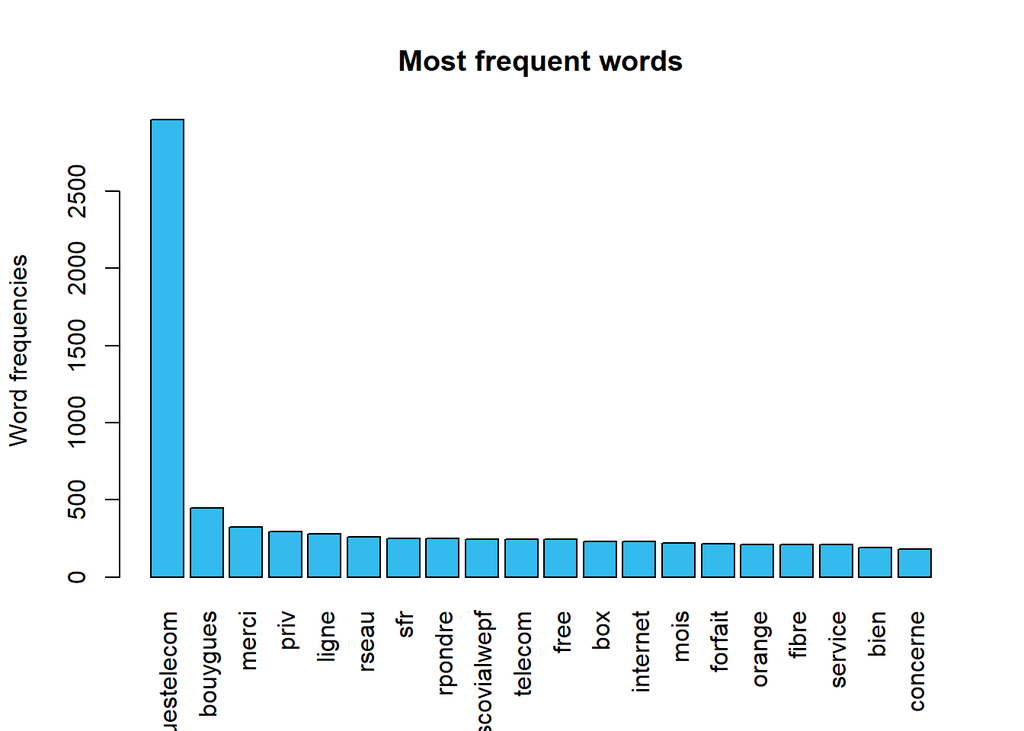

```r
barplot(d[1:20,]$freq, las = 3, names.arg = d[1:20,]$word,col ="#33BBEE", main ="Most frequent words",ylab = "Word frequencies")
```

We still find words related to the customers service but also linked to the main competitors of Bouygues Telecom. Bouyguestelecom is the most frequent word which is normal considering that we used it to do the extraction.

```r
print(text_corpusByg[[520]]$content)
```

```
## [1] "bradleyalphonse  bradleyalphonse \n\n  dm  suite   infos\n\ncharlne"
```

```r
Bouyguedata.tdm
```

```
## <<TermDocumentMatrix (terms: 7561, documents: 3888)>>
## Non-/sparse entries: 41285/29355883
## Sparsity           : 100%
## Maximal term length: 40
## Weighting          : term frequency (tf)
```

```r
findFreqTerms(Bouyguedata.tdm, lowfreq=10)[1:10]
```

```
##  [1] "bouyguestelecom" "box"             "cher"            "clair"
##  [5] "demande"         "donc"            "free"            "laisser"
##  [9] "orange"          "toute"
```

```r
Bouyguedata.tdm<-removeSparseTerms(Bouyguedata.tdm,sparse=0.95)
Bouyguedata.df <- as.data.frame(as.matrix(Bouyguedata.tdm))
```

```r
Bouyguedata.df.scale <- scale(Bouyguedata.df)
Bouyguedata.dist <- dist(Bouyguedata.df.scale,method = "euclidean")
```

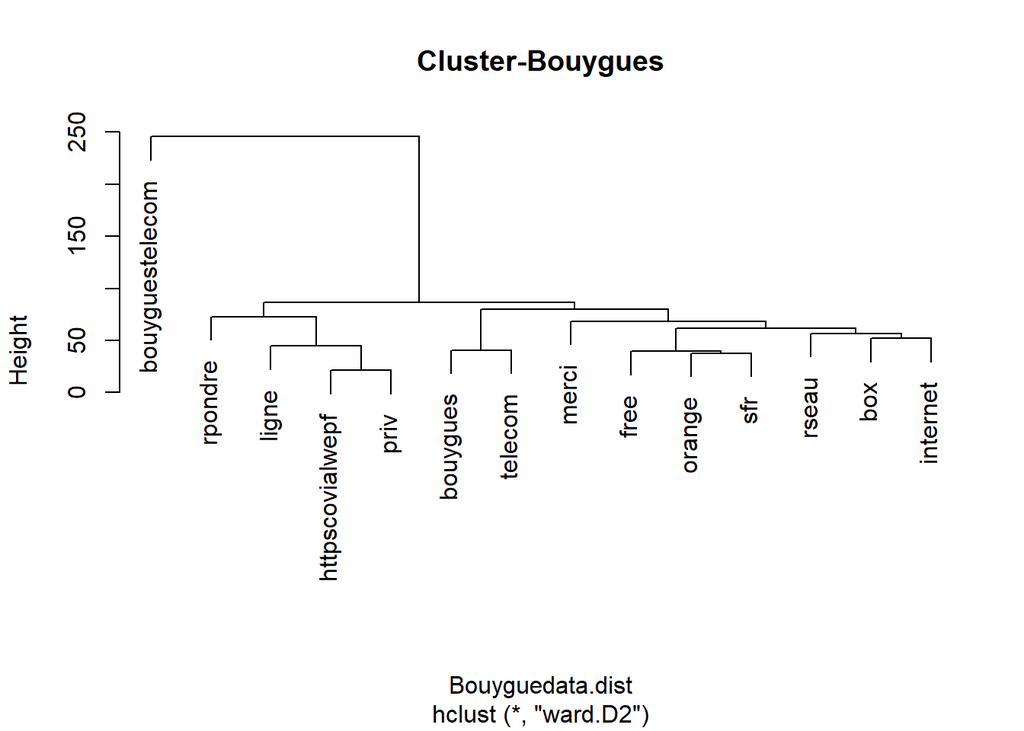

```r
Bouyguedata.fit<-hclust(Bouyguedata.dist, method="ward.D2")
plot(Bouyguedata.fit, main="Cluster-Bouygues")
```

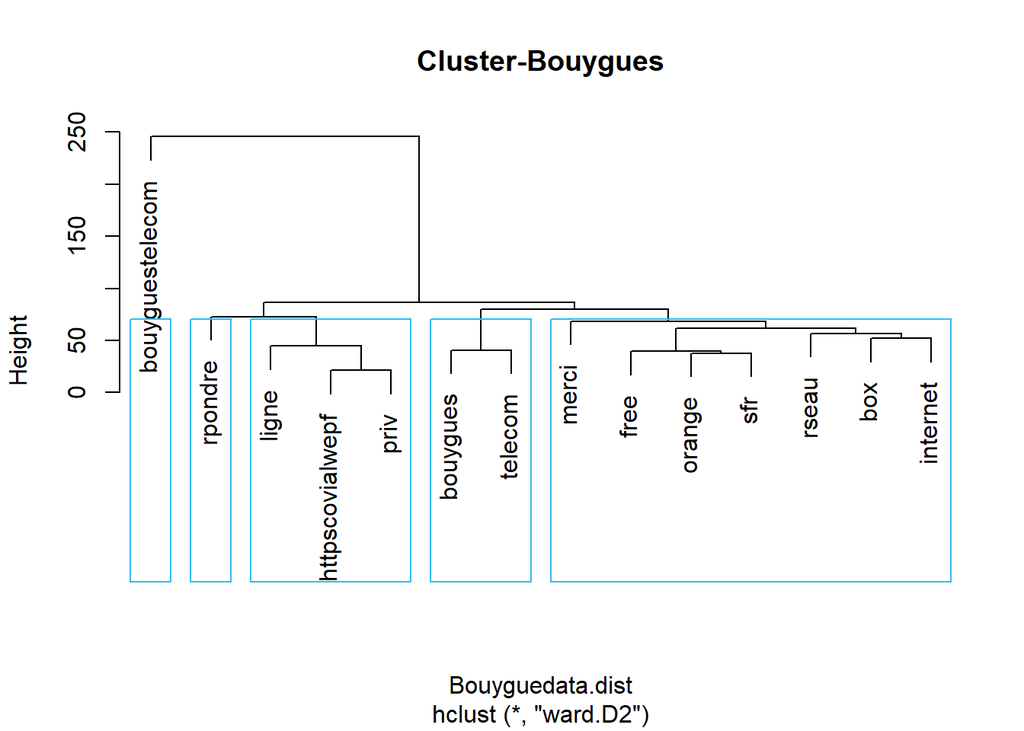

```r
groups <- cutree(Bouyguedata.fit, k=5)
plot(Bouyguedata.fit, main="Cluster-Bouygues")
rect.hclust(Bouyguedata.fit, k=5, border="#33BBEE")
```

As SFR Cluster, they are all related to customer services.

### 3.4 Hastag Analysis

A word can be considerate as a Hastag if it begins with “#”

```r
signature_hashtagByg <- regexpr("^#[[:alnum:]_]*",all_wordsByg)
list_hashtagByg <- regmatches(all_wordsByg,signature_hashtagByg)
```

Number of hastags

```r
print(length(list_hashtagByg))
```

```
## [1] 653
```

Frenquency of hastags

```r
nb_hashtagsByg <- table(list_hashtagByg)
sort_nb_hashtagsByg <- sort(nb_hashtagsByg,decreasing=TRUE)
```

Displayed of the 10 most frequent hastags

```r
hashByg = print(sort_nb_hashtagsByg[1:10])
```

```
## list_hashtagByg
## #bouyguestelecom        #bouygues        #redbysfr           #fibre
##               58               28               19               17
##              #5g              #4g         #bonplan           #nperf
##               11               10               10               10
##            #bbox             #sfr
##                9                9
```

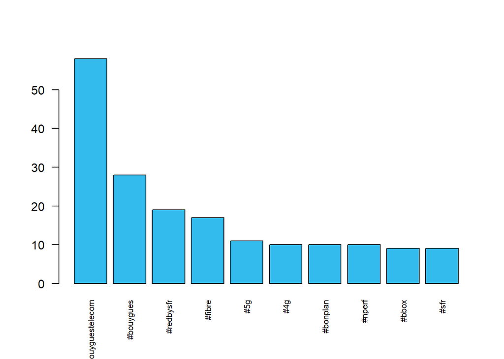

```r
barplot(sort(hashByg,decreasing=TRUE),las=2,cex.names=0.7,col="#33BBEE")
```

One of the most popular hastag is again 5G.

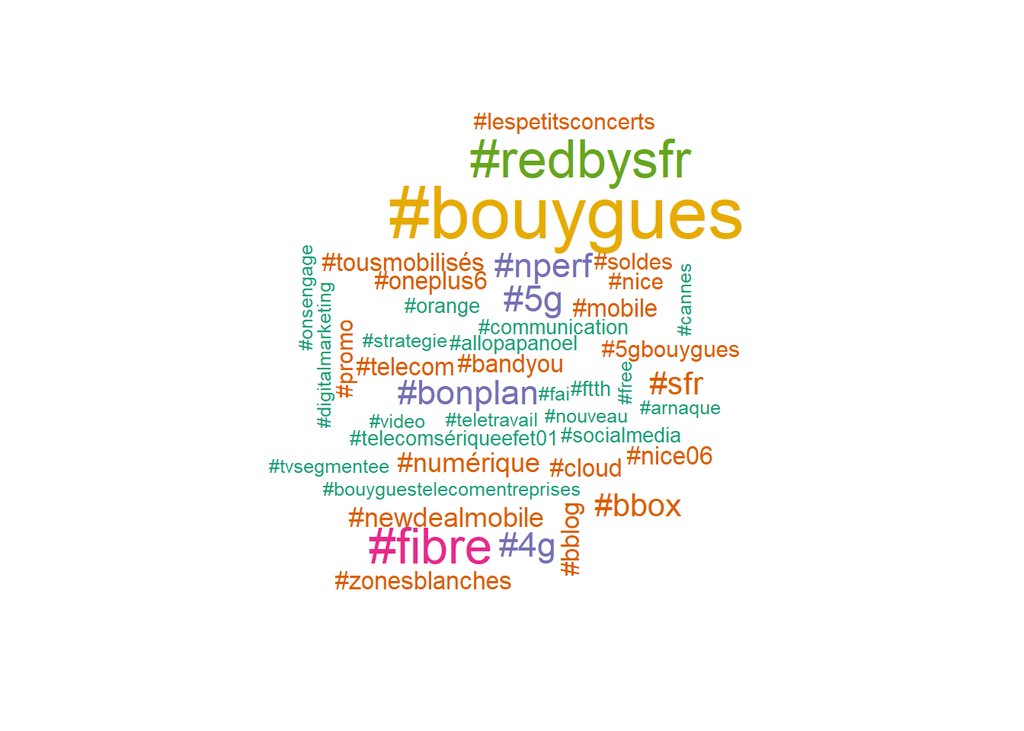

```r
wordcloud(names(sort_nb_hashtagsByg)[-1],sort_nb_hashtagsByg[-1],scale=c(3,.5),colors=brewer.pal(6, "Dark2"))
```

List of hashtags with 5G and their apparition

```r
hashtags_5gByg<- nb_hashtagsByg[grep("5g",names(nb_hashtagsByg))]
print(sort(hashtags_5gByg,decreasing=TRUE))
```

```
## list_hashtagByg
##         #5g #5gbouygues   #reseau5g  #routeur5g
##          11           5           1           1
```

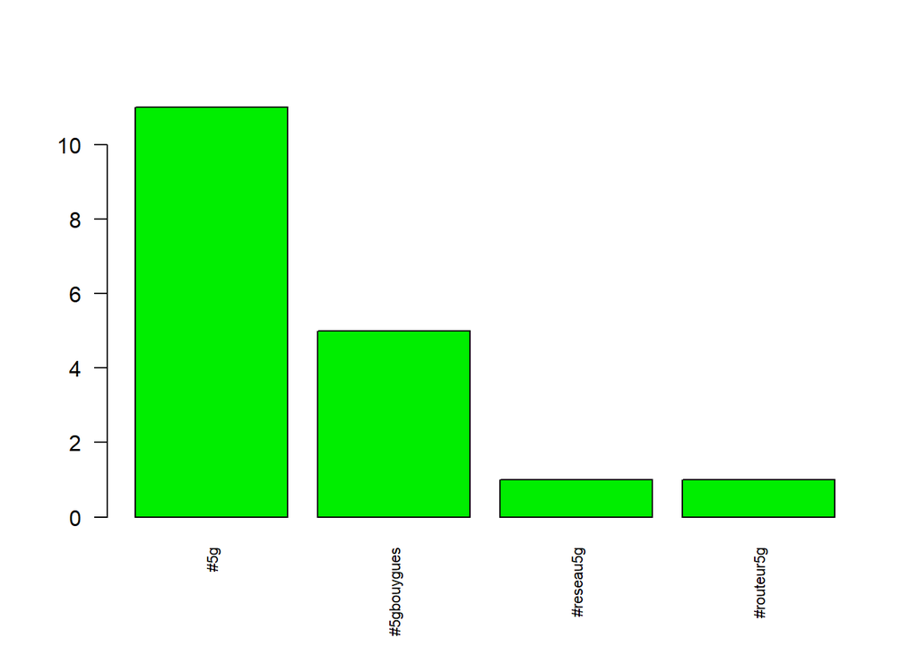

```r
barplot(sort(hashtags_5gByg,decreasing=TRUE),las=2,cex.names=0.7,col="green2")
```

#### Hashtag Network

```r
tags<-function(x) toupper(grep("#",strsplit(x," +")[[1]],value=TRUE))
l <- nrow(Bouyguedata)
taglist <- vector(mode = "list", l)
texts <- vector(mode = "character", length = l)

for (i in 1:l) texts[i] <- Bouyguedata$text[i]
texts <- iconv(texts, to = "ASCII", sub="")
```

```r
j<-0
for(i in 1:l){
  if(is.na(str_match(texts[i],"#"))[1,1]==FALSE){
    j<-j+1
    taglist[[j]]<-str_squish(removePunctuation(tags(ifelse(is.na(str_match(texts[i], "[\n]")[1,1])==TRUE,texts[i],gsub("[\n]"," ", texts[i])))))
  }
}

alltags <- NULL
for (i in 1:l) alltags<-union(alltags,taglist[[i]])

hash.graph <- graph.empty(directed = T)

hash.graph <- hash.graph + vertices(alltags)

for (tags in taglist){
  if (length(tags)>1){
    for (pair in combn(length(tags),2,simplify=FALSE, FUN=function(x) sort(tags[x]))){
      if (pair[1]!=pair[2]) {
        if (hash.graph[pair[1],pair[2]]==0)
          hash.graph<-hash.graph+edge(pair[1],pair[2])
      }
    }
  }
}
```

```r
V(hash.graph)$color <- "blue"
E(hash.graph)$color <- "black"
V(hash.graph)$name <- paste("#",V(hash.graph)$name, sep = "")
V(hash.graph)$label.cex = 0.75
V(hash.graph)$size <- 12
V(hash.graph)$size2 <- 2
hash.graph_simple<-delete.vertices(simplify(hash.graph),
                                   degree(hash.graph)<=10)
```

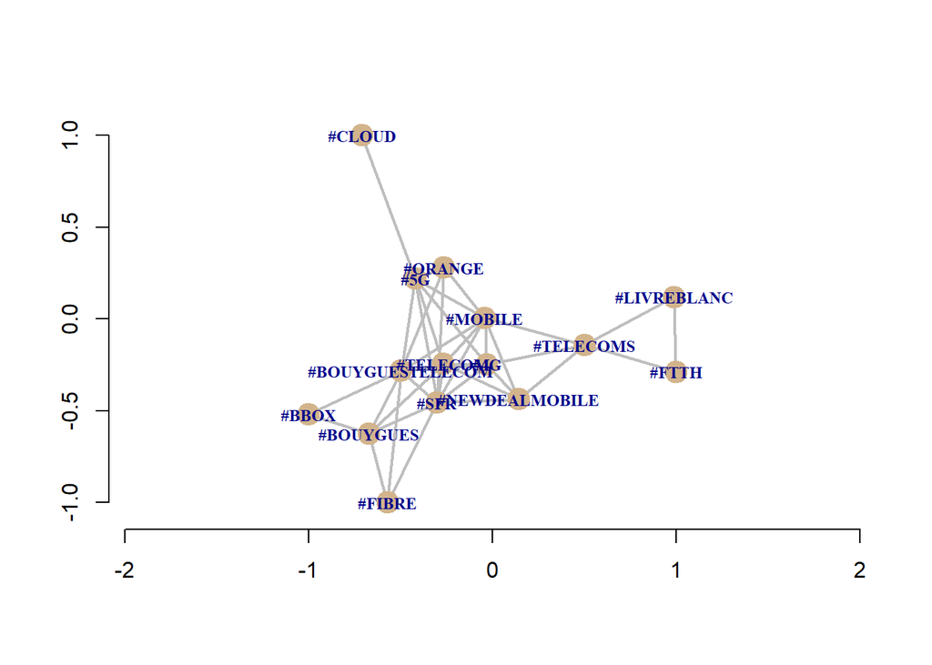

```r
plot(hash.graph_simple, edge.width = 2,
     edge.color = "grey", vertex.color = "tan",
     vertex.frame.color="tan", label.color = "blue",
     vertex.label.font=2, edge.arrow.size=0,5)
```

We can clearly identify the main topics: the competitors, the new offers as BBOX, Cloud linked to 5G and 5G.

### 3.5 Sentiment analysis

```r
plain.text<-vector()
for(i in 1:dim(Bouyguedata)[1]){
  plain.text[i]<-Bouyguedata_corpus[[i]][[1]]
}
```

```r
sentence_sentiment<-sentiment(get_sentences(plain.text))
sentence_sentiment
```

```
##       element_id sentence_id word_count  sentiment
##    1:          1           1          5 0.00000000
##    2:          2           1         17 0.12126781
##    3:          3           1          9 0.00000000
##    4:          4           1          2 0.00000000
##    5:          5           1          3 0.00000000
##   ---
## 3884:       3884           1         14 0.00000000
## 3885:       3885           1          3 0.00000000
## 3886:       3886           1          9 0.00000000
## 3887:       3887           1         20 0.11180340
## 3888:       3888           1         21 0.02182179
```

```r
average_sentiment<-mean(sentence_sentiment$sentiment)
average_sentiment
```

```
## [1] 0.02708945
```

As SFR, Bouygues Telecom uses its twitter account as a custumer services so it can explain why the average is around zero.

```r
extract_sentiment_terms(get_sentences(plain.text))
```

```
##       element_id sentence_id negative positive
##    1:          1           1
##    2:          2           1              free
##    3:          3           1
##    4:          4           1
##    5:          5           1
##   ---
## 3884:       3884           1
## 3885:       3885           1
## 3886:       3886           1
## 3887:       3887           1              free
## 3888:       3888           1   demand surprise
```

### 3.6 Topic Modeling

```r
text_corpus2Byg<-text_corpusByg[1:200]
doc.lengths<-rowSums(as.matrix(DocumentTermMatrix(text_corpus2Byg)))
dtm <- DocumentTermMatrix(text_corpus2Byg[doc.lengths > 0])
```

```r
SEED = sample(1:1000000, 1)
```

```r
k = 2
Topics_results<-LDA(dtm, k = k, control = list(seed = SEED))
```

```r
terms(Topics_results,15)
```

```
##       Topic 1           Topic 2
##  [1,] "priv"            "bouyguestelecom"
##  [2,] "ligne"           "rpondre"
##  [3,] "httpscovialwepf" "httpscovialwepf"
##  [4,] "bouyguestelecom" "pensez"
##  [5,] "point"           "concerne"
##  [6,] "privs"           "indiquer"
##  [7,] "suivre"          "kugucu"
##  [8,] "concerne"        "ligne"
##  [9,] "puissiez"        "dumieletdusole"
## [10,] "essayons"        "messages"
## [11,] "recevoir"        "mieux"
## [12,] "messages"        "demande"
## [13,] "dumieletdusole"  "recevoir"
## [14,] "bouygues"        "bonne"
## [15,] "ensemble"        "mdr"
```

```r
topics(Topics_results)
```

```
##   1   2   3   4   5   6   7   8   9  10  11  12  13  14  15  16  17  18  19  20
##   2   2   1   2   2   2   2   2   1   2   2   2   1   2   2   1   2   1   2   2
##  21  22  23  24  25  26  27  28  29  30  31  32  33  34  35  36  37  38  39  40
##   2   2   2   2   2   2   2   2   2   2   2   1   2   2   1   2   1   2   2   2
##  41  42  43  44  45  46  47  48  49  50  51  52  53  54  55  56  57  58  59  60
##   2   1   2   2   2   2   2   2   2   2   1   2   2   2   1   2   2   2   1   1
##  61  62  63  64  65  66  67  68  69  70  71  72  73  74  75  76  77  78  79  80
##   2   1   1   2   2   2   2   1   2   1   2   2   2   2   2   2   1   1   2   2
##  81  82  83  84  85  86  87  88  89  90  91  92  93  94  95  96  97  98  99 100
##   2   2   1   1   2   1   2   2   1   2   1   2   2   1   1   1   1   2   1   1
## 101 102 103 104 105 106 107 108 109 110 111 112 113 114 115 116 117 118 119 120
##   1   2   1   2   2   1   1   2   1   2   2   1   2   2   1   1   1   1   1   2
## 121 122 123 124 125 126 127 128 129 130 131 132 133 134 135 136 137 138 139 140
##   2   1   2   1   1   1   1   2   1   1   1   1   2   1   2   1   2   2   1   2
## 141 142 143 144 145 146 147 148 149 150 151 152 153 154 155 156 157 158 159 160
##   1   1   2   1   1   1   1   1   1   1   1   1   1   1   1   1   1   2   2   2
## 161 162 163 164 165 166 167 168 169 170 171 172 173 174 175 176 177 178 179 180
##   1   1   2   1   2   1   1   1   1   1   2   1   1   1   1   2   1   1   1   2
## 181 182 183 184 185 186 187 188 189 190 191 192 193 194 195 196 197 198 199 200
##   1   1   2   1   2   1   2   1   2   1   1   1   1   1   1   1   1   1   1   1
```

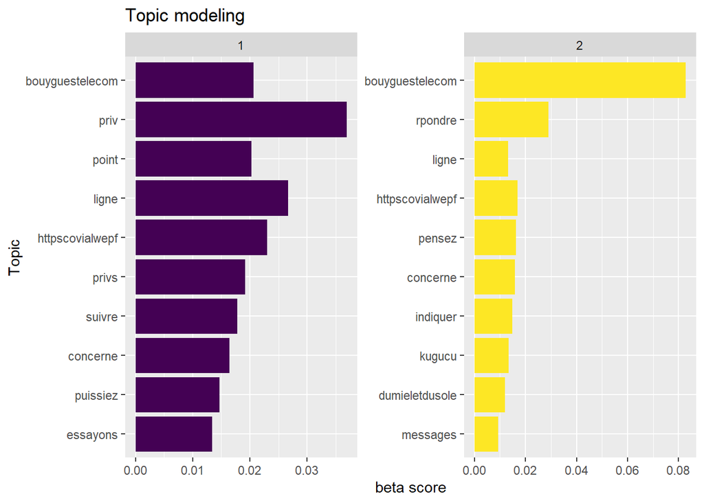

```r
tidy_model_beta<-tidy(Topics_results, matrix = "beta")
tidy_model_beta %>%
  group_by(topic) %>%
  top_n(10, beta) %>%
  ungroup() %>%
  arrange(topic, -beta) %>%
  ggplot(aes(reorder(term, beta),beta,fill=factor(topic)))+
  geom_col(show.legend = FALSE) +
  facet_wrap(~ topic, scales = "free") +
  scale_fill_viridis_d() +
  coord_flip() +
  labs(x = "Topic",
       y = "beta score",
       title = "Topic modeling")
```

Same as SFR, the first Topic seems related to the customer questions and the second one to the customer service answers and help.

## 4. Analysis of 5G

### 4.1 Clean and Exploratory Analysis

```r
class(data5G)
```

```
## [1] "tbl_df"     "tbl"        "data.frame"
```

```r
head(data5G, n=2)
```

```
## # A tibble: 2 x 90
##   user_id status_id created_at          screen_name text  source
##   <chr>   <chr>     <dttm>              <chr>       <chr> <chr>
## 1 420347~ 13545491~ 2021-01-27 21:57:29 aserbert    "Apr~ Twitt~
## 2 911082~ 13545490~ 2021-01-27 21:57:04 Aristophan~ "La ~ Twitt~
## # ... with 84 more variables: display_text_width <dbl>,
## #   reply_to_status_id <chr>, reply_to_user_id <chr>,
## #   reply_to_screen_name <chr>, is_quote <lgl>, is_retweet <lgl>,
## #   favorite_count <int>, retweet_count <int>, quote_count <int>,
## #   reply_count <int>, hashtags <list>, symbols <list>, urls_url <list>,
## #   urls_t.co <list>, urls_expanded_url <list>, media_url <list>,
## #   media_t.co <list>, media_expanded_url <list>, media_type <list>,
## #   ext_media_url <list>, ext_media_t.co <list>, ext_media_expanded_url <list>,
## #   ext_media_type <chr>, mentions_user_id <list>, mentions_screen_name <list>,
## #   lang <chr>, quoted_status_id <chr>, quoted_text <chr>,
## #   quoted_created_at <dttm>, quoted_source <chr>, quoted_favorite_count <int>,
## #   quoted_retweet_count <int>, quoted_user_id <chr>, quoted_screen_name <chr>,
## #   quoted_name <chr>, quoted_followers_count <int>,
## #   quoted_friends_count <int>, quoted_statuses_count <int>,
## #   quoted_location <chr>, quoted_description <chr>, quoted_verified <lgl>,
## #   retweet_status_id <chr>, retweet_text <chr>, retweet_created_at <dttm>,
## #   retweet_source <chr>, retweet_favorite_count <int>,
## #   retweet_retweet_count <int>, retweet_user_id <chr>,
## #   retweet_screen_name <chr>, retweet_name <chr>,
## #   retweet_followers_count <int>, retweet_friends_count <int>,
## #   retweet_statuses_count <int>, retweet_location <chr>,
## #   retweet_description <chr>, retweet_verified <lgl>, place_url <chr>,
## #   place_name <chr>, place_full_name <chr>, place_type <chr>, country <chr>,
## #   country_code <chr>, geo_coords <list>, coords_coords <list>,
## #   bbox_coords <list>, status_url <chr>, name <chr>, location <chr>,
## #   description <chr>, url <chr>, protected <lgl>, followers_count <int>,
## #   friends_count <int>, listed_count <int>, statuses_count <int>,
## #   favourites_count <int>, account_created_at <dttm>, verified <lgl>,
## #   profile_url <chr>, profile_expanded_url <chr>, account_lang <lgl>,
## #   profile_banner_url <chr>, profile_background_url <chr>,
## #   profile_image_url <chr>
```

Number of location represented:

```r
length(unique(data5G$location))
```

```
## [1] 1427
```

```r
data5G$location2<-iconv(data5G$location,to = "ASCII", sub="")
```

Location list

```r
data5G$location2[data5G$location2==""]<- NA
data5G$location2[data5G$location2==", "]<- NA
data5G$location2[data5G$location2=="Paris"]<- "Paris, France"
data5G$location2[data5G$location2=="Bordeaux"]<- "Bordeaux, France"
data5G$location2[data5G$location2=="Marseille"]<- "Marseille, France"
data5G$location2[data5G$location2=="Nice"]<- "Nice, France"
data5G$location2[data5G$location2=="Lille"]<- "Lille, France"
data5G$location2[data5G$location2=="Lyon"]<- "Lyon, France"
data5G$location2[data5G$location2=="Toulouse"]<- "Toulouse, France"
data5G$location2[data5G$location2=="Paris, Ile-de-France"]<- "Paris, France"
data5G$location2[data5G$location2=="Ile-de-France, France"]<- "Paris, France"
```

#### Twitter users - unique locations

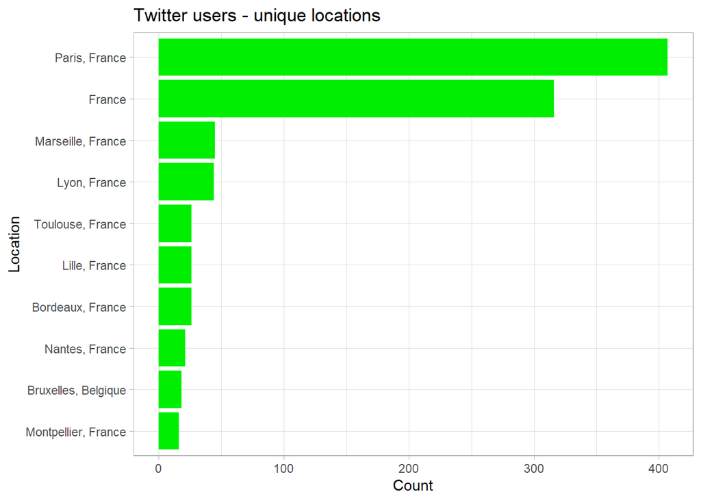

```r
data5G %>%count(location2, sort=TRUE) %>%
mutate(location2=reorder(location2,n)) %>%
na.omit()%>% top_n(10)%>%ggplot(aes(x=location2,y=n))+ geom_bar(stat="identity")+ geom_col(fill='green2')+ coord_flip() +
labs(x = "Location", y = "Count",title = "Twitter users - unique locations ")+ theme_light()
```

#### Time series of tweets counts

Plot time series of tweets

[figure not shown]

```r
ts_plot(data5G, "hours")+
ggplot2::theme_minimal()+
ggplot2::theme(plot.title=ggplot2::element_text(face="bold"))+
ggplot2::labs(x=NULL,y=NULL,
title="Frequency of SFR Twitter statuses",
subtitle="Twitter status counts 1-hour intervals",
caption="\nSource: Data collected from Twitter's API")
```

We can see a huge pic on the evening of the 26 January, it can be explain by the diffusion on BFM Business of an interview about the Use of 5G.

```r
tweets5G.df <-as.data.frame(data5G)
print(dim(tweets5G.df))
```

```
## [1] 5000   91
```

```r
print(colnames(tweets5G.df))
```

```
##  [1] "user_id"                 "status_id"
##  [3] "created_at"              "screen_name"
##  [5] "text"                    "source"
##  [7] "display_text_width"      "reply_to_status_id"
##  [9] "reply_to_user_id"        "reply_to_screen_name"
## [11] "is_quote"                "is_retweet"
## [13] "favorite_count"          "retweet_count"
## [15] "quote_count"             "reply_count"
## [17] "hashtags"                "symbols"
## [19] "urls_url"                "urls_t.co"
## [21] "urls_expanded_url"       "media_url"
## [23] "media_t.co"              "media_expanded_url"
## [25] "media_type"              "ext_media_url"
## [27] "ext_media_t.co"          "ext_media_expanded_url"
## [29] "ext_media_type"          "mentions_user_id"
```

[output cut: 31 more lines]

```r
print(tweets5G.df[1:10,c('created_at','screen_name','is_retweet','hashtags')])
```

```
##             created_at     screen_name is_retweet                 hashtags
## 1  2021-01-27 21:57:29        aserbert       TRUE                       NA
## 2  2021-01-27 21:57:04 AristophaneGomi       TRUE                       NA
## 3  2021-01-26 14:44:28 AristophaneGomi      FALSE                       NA
## 4  2021-01-26 14:43:39 AristophaneGomi       TRUE NUMÉRIQUE, FranceRelance
## 5  2021-01-26 16:15:39 AristophaneGomi       TRUE       CSFInfraNumériques
## 6  2021-01-26 14:35:45 AristophaneGomi       TRUE                 InfraNum
## 7  2021-01-27 21:56:51  Carmen66594485       TRUE                       NA
## 8  2021-01-27 21:56:40   FredericDufal       TRUE                       NA
## 9  2021-01-27 21:55:00     LorisLouis3       TRUE                GalaxyS21
## 10 2021-01-27 21:54:12        leaa_stl      FALSE                       NA
```

#### Analysis of the writtors of the tweets

```r
NBperusers2 <- table(tweets5G.df$screen_name)
NBperusers2<- sort(NBperusers2,decreasing=TRUE)
print(NBperusers2[1:10])
```

```
##
## Digitaltrans4mF        TiinoX83      FFTelecoms        urlututu          _blat_
##              20              12              11              10               9
##    AliceFlahaut bouyguestelecom   fabienprevots      GIRLZWKOOK    Sa7894394374
##               9               9               9               9               9
```

Digitaltrans4mF wrote the highest number of tweets

```r
print(length(unique(tweets5G.df$screen_name)))
```

```
## [1] 4147
```

Barplot of users that wrote more than 8 tweets.

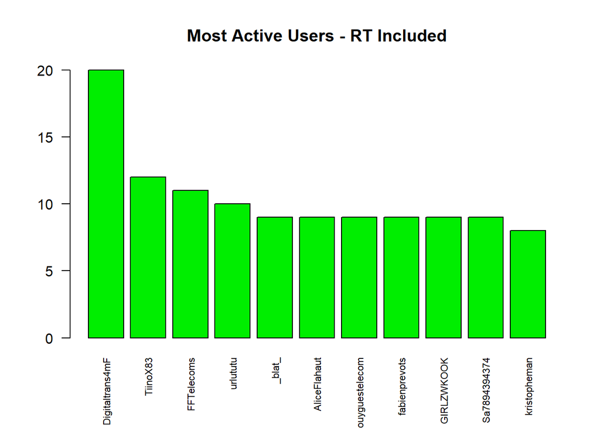

```r
barplot(NBperusers2 [NBperusers2 >= 8], las = 2,cex.names=0.7,col="green2", main='Most Active Users - RT Included')
```

#### Original Tweets without the RT

```r
id_original2 <- which(!tweets5G.df$is_retweet)
print(length(id_original2))
```

```
## [1] 2543
```

Number of original tweets per users

```r
NBperusers_2 <- table(tweets5G.df$screen_name[id_original2])
NBperusers_2 <- sort(NBperusers_2,decreasing=TRUE)
```

[figure not shown]

```r
barplot(NBperusers_2 [NBperusers_bis >= 10], las = 2,cex.names=0.7, col = "green2", main='Most Active Users - Without RT')
```

### 4.2 Analysis of the Users

We first create a data.frame with the original message Removing of the duplicate

```r
originalmsg5g.df <- tweets5G.df[!duplicated(tweets5G.df$text),]
```

Number of tweets without duplicate:

```r
print(nrow(originalmsg5g.df))
```

```
## [1] 2665
```

We collect in a specify vector :

```r
messages5g <- originalmsg5g.df$text
```

```r
print(length(messages5g))
```

```
## [1] 2665
```

Verification of the lenght

```r
print(messages5g[1])
```

```
## [1] "Après Huawei, Xiaomi. L'offensive chinoise dans les réseaux, notamment 5G, devrait a minima nous interroger, au mieux nous faire garder les sites de R&amp;D de #Nokia Alcatel. Nos gouvernants sont ils aveugles, lâches ou corrompus ? https://t.co/nYbyzsHokS"
```

```r
msgClean5g <- iconv(messages5g, to = "ASCII", sub="")
msgClean5g <- gsub("\n"," ",messages5g)
msgClean5g <- gsub('http\\S+\\s*',"",msgClean5g)
msgClean5g <- gsub("\\s+"," ",msgClean5g)
msgClean5g <- gsub("[\\]","",msgClean5g)
msgClean5g <- gsub("\\s*$","",msgClean5g)
msgClean5g <- tolower(msgClean5g)
msgClean5g <- gsub("[éèê]","e",msgClean5g)
msgClean5g <- gsub("[àâ]","a",msgClean5g)
msgClean5g <- gsub("[ùû]","u",msgClean5g)
msgClean5g <- gsub("rt ","",msgClean5g)
```

Verification of the message 1

```r
print(msgClean5g[1])
```

```
## [1] "apres huawei, xiaomi. l'offensive chinoise dans les reseaux, notamment 5g, devrait a minima nous interroger, au mieux nous faire garder les sites de r&amp;d de #nokia alcatel. nos gouvernants sont ils aveugles, laches ou corrompus ?"
```

Remove of the duplicates

```r
msgClean5g <- msgClean5g[!duplicated(msgClean5g)]
```

Numbers of tweets messages

```r
print(length(msgClean5g))
```

```
## [1] 2622
```

Isolate each word between spaces

```r
all_words5g <- unlist(strsplit(msgClean5g," "))
```

On the text to dermine a user we can looking for “@”

```r
signature_users5g <- regexpr("^@[[:alnum:]_]*",all_words5g)
```

```r
list_users5g <- regmatches(all_words5g,signature_users5g)
```

```r
print(length(list_users5g))
```

```
## [1] 3355
```

Aparition of the users

```r
nb_users5g <- table(list_users5g)
sort_nb_users5g <- sort(nb_users5g,decreasing=TRUE)
```

Most frequent users

```r
print(sort_nb_users5g[1:10])
```

```
## list_users5g
##         @zerator @bouyguestelecom      @freemobile    @romainlanery
##               55               39               32               28
##            @free      @mediavenir           @booba             @sfr
##               23               22               20               20
##        @cedric_o        @danubaud
##               18               18
```

On the top 10 of the users of the hastag 5g, we found some of the 4 biggest french operators. Thus, it shows us their will to enter on this wave of numerical transformation.

### 4.3 Cluster analysis

```r
usableText5g <- iconv(data5G$text, to = "ASCII", sub="")
```

```r
data5g_corpus<-Corpus(VectorSource(usableText5g))

data5g_corpus<-tm_map(data5g_corpus,tolower)
```

```r
data5g_corpus<-tm_map(data5g_corpus,function(x)removeWords(x,stopwords("french")))
data5g_corpus<-tm_map(data5g_corpus,removePunctuation)

data5g_corpus<-tm_map(data5g_corpus,removeNumbers)
data5g_corpus<-tm_map(data5g_corpus,removeWords,c("chez","faire","tout","jai","tout","fait","cest","plus","dites","quand","mme","meme","passe","rien","depuis","pouvez","tre","juste","peu","dit","sinon","dus","parce"))
text_corpus5g <- tm_map(data5g_corpus,content_transformer(function(x) iconv(x,to='ASCII',sub='byte')))
```

```r
data5g.tdm <- TermDocumentMatrix(text_corpus5g)
m2 <- as.matrix(data5g.tdm)
m2[1:10,1:10]
```

```
##                    Docs
## Terms               1 2 3 4 5 6 7 8 9 10
##   alcatel           1 0 0 0 0 0 0 0 0  0
##   aprs              1 0 0 0 0 0 0 0 0  0
##   aveugles          1 0 0 0 0 0 0 0 0  0
##   chinoise          1 0 0 0 0 0 0 0 0  0
##   corrompus         1 0 0 0 0 0 0 0 0  0
##   devrait           1 0 0 0 0 0 0 0 0  0
##   garder            1 0 0 0 0 0 0 0 0  0
##   gouvernants       1 0 0 0 0 0 0 0 0  0
##   httpsconybyzshoks 1 0 0 0 0 0 0 0 0  0
##   huawei            1 0 0 0 0 0 0 0 0  0
```

```r
v2 <- sort(rowSums(m2),decreasing=TRUE)
d2 <- data.frame(word = names(v2),freq=v2)
head(d2, 50)
```

```
##                                word freq
## reconnaissance       reconnaissance  645
## faciale                     faciale  643
## huawei                       huawei  603
## chine                         chine  518
## tlphone                     tlphone  514
## vaccin                       vaccin  441
## merci                         merci  405
## production               production  358
## macron                       macron  354
## regarder                   regarder  349
## vidosurveillance   vidosurveillance  344
## gouvernement           gouvernement  341
## dvelopper                 dvelopper  340
## courant                     courant  329
## vidos                         vidos  328
## risquez                     risquez  326
## vies                           vies  322
## marche                       marche  320
## dictature                 dictature  319
## impact                       impact  319
## social                       social  312
## espionnage               espionnage  311
## crdit                         crdit  310
## pkin                           pkin  310
## roule                         roule  310
## chinoisepour           chinoisepour  309
## franceavec               franceavec  309
## lentreprise             lentreprise  309
## sentez                       sentez  309
## httpscocowoumggqf httpscocowoumggqf  305
## covid                         covid  291
## aprs                           aprs  279
## projet                       projet  233
## selon                         selon  233
## utilisation             utilisation  223
## contre                       contre  222
## trs                             trs  217
## alsace                       alsace  207
## premier                     premier  207
## oui                             oui  200
## site                           site  199
## devrait                     devrait  197
## notamment                 notamment  197
## note                           note  193
## redmi                         redmi  188
## dquipements             dquipements  186
## janvier                     janvier  183
## hors                           hors  183
## quipements               quipements  183
## orange                       orange  180
```

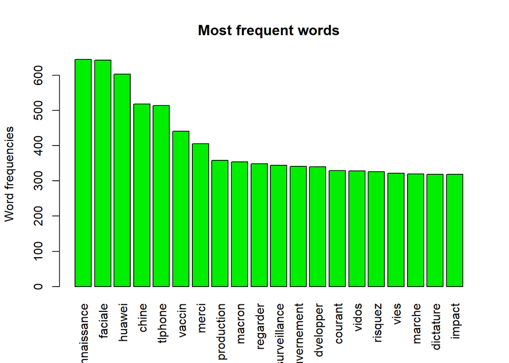

```r
barplot(d2[1:20,]$freq, las = 3, names.arg = d2[1:20,]$word,col ="green2", main ="Most frequent words",ylab = "Word frequencies")
```

Huawei is part of the most mentionned words because the Huawei phones are excluded from the french 5G network. We can also see the doubts of French people (covid, risquez, surveillance…)

```r
print(text_corpus5g[[1]]$content)
```

```
## [1] "aprs huawei xiaomi offensive chinoise   rseaux notamment g devrait a minima  interroger  mieux   garder  sites  ramp  nokia alcatel  gouvernants   aveugles lches  corrompus  httpsconybyzshoks"
```

#### 5G terms frequency

```r
data5g.tdm
```

```
## <<TermDocumentMatrix (terms: 11136, documents: 5000)>>
## Non-/sparse entries: 67120/55612880
## Sparsity           : 100%
## Maximal term length: 34
## Weighting          : term frequency (tf)
```

```r
findFreqTerms(data5g.tdm, lowfreq=10)[1:10]
```

```
##  [1] "aprs"       "chinoise"   "devrait"    "garder"     "huawei"
##  [6] "interroger" "mieux"      "nokia"      "notamment"  "ramp"
```

```r
data5g.tdm<-removeSparseTerms(data5g.tdm,sparse=0.95)
data5g.df <- as.data.frame(as.matrix(data5g.tdm))
```

```r
data5g.df.scale <- scale(data5g.df)
data5g.dist <- dist(data5g.df.scale,method = "euclidean")
```

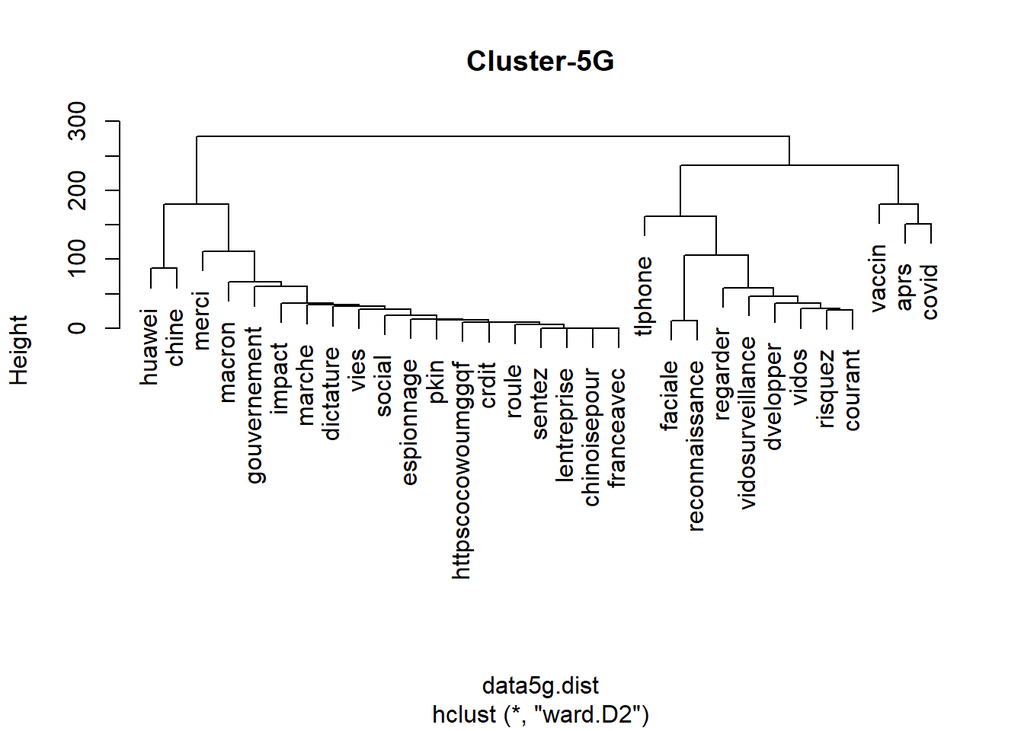

```r
data5g.fit<-hclust(data5g.dist, method="ward.D2")
plot(data5g.fit, main="Cluster-5G")
```

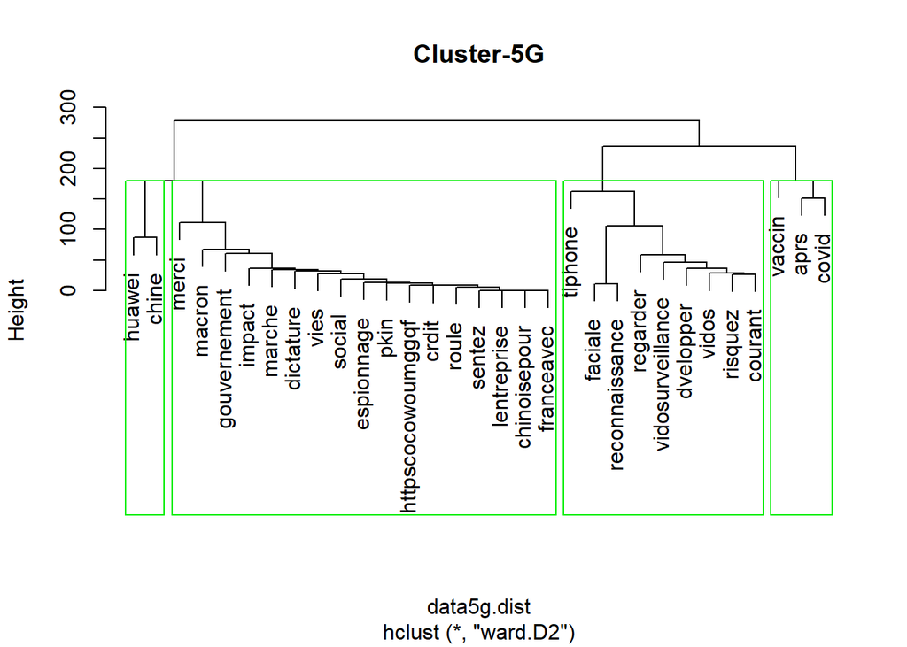

```r
groups5g <- cutree(data5g.fit, k=4)
plot(data5g.fit, main="Cluster-5G")
rect.hclust(data5g.fit, k=4, border="green2")
```

Cluster 1: the Huawei polemic about its exclusion in the 5G French network.

Cluster 2 & 3: mostly about the doubts, uncertainty, mass surveillance of the population.

Cluster 4: The rumor about the correlation between the 5G network and the Covid vaccine.